## pSERG: Factors Associated with Long-Term Outcomes in Pediatric RSE

## Install needed packages

This step loads packages with functions needed for analysis and that are not present in base R.

```r
#install.packages("gdata")
library(gdata)
#install.packages("car")
library(car)
#install.packages("gmodels")
library(gmodels)
#install.packages("lubridate")
library(lubridate)
#install.packages("mediation")
library(mediation)
```

##Load database

```r
pSERG = read.csv("C:\\Users\\crist\\Desktop\\pSERG_LTO_10.19.20.csv")
dim(pSERG)
```

```
## [1]  825 1582
```

##Data cleaning and data transformation The main objectives in this block of code are: 1) keep only patients with refractory convulsive SE, 2) keep only the first SE episode for each patient, 3) keep only patient who were alive at discharge, 4) transform variables for easier analysis, 5) delete patients wtih missing data on crucial variables

```r
# Keep only refractory patients
pSERG <- pSERG[which(pSERG$SE_GROUP == "refractory_case"), ]
dim(pSERG)
```

```
## [1]  490 1582
```

```r
# Transform date of status epilepticus onset into date format
pSERG$DATESEIZURE <- as.Date(pSERG$DATESEIZURE, format = "%m/%d/%Y")

# Order by date of status epilepticus
pSERG <- pSERG[order(pSERG$DATESEIZURE), ]

# Order by patient label
pSERG <- pSERG[order(pSERG$PATIENT_LABEL), ]

# Delete duplicate episodes from the same patient
pSERG <- pSERG[!duplicated(pSERG$PATIENT_LABEL), ]
dim(pSERG)
```

```
## [1]  431 1582
```

```r
# Keep only patients with info regarding in-hospital mortality and who were alive at discharge
pSERG$ALIVE[pSERG$ALIVE == ""] <- NA
pSERG <- pSERG[complete.cases(pSERG[ ,"ALIVE"]), ]
CrossTable(pSERG$ALIVE)
```

```
##
##
##    Cell Contents
## |-------------------------|
## |                       N |
## |         N / Table Total |
## |-------------------------|
##
##
## Total Observations in Table:  403
##
##
##           |        no |       yes |
##           |-----------|-----------|
##           |        16 |       387 |
##           |     0.040 |     0.960 |
##           |-----------|-----------|
##
##
##
##
```

```r
# Keep only patients who were alive at discharge
pSERG = pSERG[which(pSERG$ALIVE == "yes"), ]
dim(pSERG)
```

```
## [1]  387 1582
```

```r
# --- Age
# Transform age into numeric
pSERG$G_T_STTS_PLPTCUS_EPISODE_YEARS <- as.numeric(as.character(pSERG$G_T_STTS_PLPTCUS_EPISODE_YEARS))
pSERG$G_T_STTS_PLPTCS_EPISODE_MONTHS <- as.numeric(as.character(pSERG$G_T_STTS_PLPTCS_EPISODE_MONTHS))
# Transform age into a single variable with age in years
pSERG$ageyears <- pSERG$G_T_STTS_PLPTCUS_EPISODE_YEARS + (pSERG$G_T_STTS_PLPTCS_EPISODE_MONTHS / 12)

# Keep only patients with info regarding age
pSERG <- pSERG[complete.cases(pSERG[ ,"ageyears"]), ]
dim(pSERG)
```

```
## [1]  381 1583
```

```r
# --- Sex
# Create variable SEX
pSERG$SEX <- ifelse(pSERG$SEX == "male", 1, 0)
table(pSERG$SEX)
```

```
##
##   0   1
## 172 209
```

```r
# Keep only patients with info regarding sex
pSERG <- pSERG[complete.cases(pSERG[ ,"SEX"]), ]
dim(pSERG)
```

```
## [1]  381 1583
```

```r
# --- Race
# Delete patients with unknown race
pSERG <- pSERG[complete.cases(pSERG[ , "RACE"]), ]
dim(pSERG)
```

```
## [1]  381 1583
```

```r
# --- Ethnicity
# Delete patients with unknown ethnicity
pSERG <- pSERG[complete.cases(pSERG[ , "ETHNICITY"]), ]
dim(pSERG)
```

```
## [1]  381 1583
```

```r
#--- Seizure duration (convulsive+EEG duration)
class(pSERG$SEIZUREDURATION)
```

```
## [1] "factor"
```

```r
# Change class from factor to numeric
pSERG$SEIZUREDURATION <- as.character(as.factor(pSERG$SEIZUREDURATION))
pSERG$SEIZUREDURATION <- as.numeric(as.character(pSERG$SEIZUREDURATION))
class(pSERG$SEIZUREDURATION)
```

```
## [1] "numeric"
```

```r
# Create subsets according to units
table(pSERG$SEIZUREDURATIONUNITS)
```

```
##
##     day  hr min
##   1  32 128 220
```

```r
hr = subset(pSERG, pSERG$SEIZUREDURATIONUNITS == "hr")
day = subset(pSERG, pSERG$SEIZUREDURATIONUNITS == "day")
min = subset(pSERG, pSERG$SEIZUREDURATIONUNITS == "min")

hr$SEIZUREDURATION
```

```
##   [1]   2.00   6.00   5.50   3.50  29.00   6.50   3.00   4.50   1.50   2.00
##  [11]   1.00  28.50  24.00   9.00   3.50  17.00  25.00   2.00   9.00   5.50
##  [21]   7.50  18.50   2.50  18.00 576.00   2.50   5.00   6.00   3.00   3.00
##  [31]   7.00 115.00 129.00 106.00 106.00  44.50  24.00  30.00  28.00  11.75
##  [41]   3.00  56.25  36.22  18.75   3.02  21.90  30.00  12.70   1.00 104.00
##  [51]   2.00   9.00  48.00     NA     NA  38.00   4.00  69.00   2.00   1.00
##  [61] 880.00   2.00  44.00   2.00   3.00   5.00  22.00  39.00  28.00   9.00
##  [71]  72.00  22.00   6.50   4.50  26.50   3.00   9.50   4.00 240.00  14.00
##  [81]  10.50   3.00   2.00   4.00   5.50  19.00  13.50  56.00  23.00  10.00
##  [91]     NA   3.00   7.00   6.00  11.00  33.00   6.00  12.00  16.00  36.00
## [101]     NA  13.50  48.00  11.00  48.00  16.00  33.00   5.00   8.00  29.75
## [111]  26.00  13.00   6.00  10.75  30.75  21.00   5.00   4.00 376.00   4.00
## [121]  48.00   1.00  65.00   3.00   6.00   8.00   5.00   5.00
```

```r
day$SEIZUREDURATION
```

```
##  [1] 50.00  6.00 36.00 25.00  7.00 15.00 22.00 10.00 63.00  2.00  6.00 10.00
## [13]  2.00  5.00  4.00  4.00  3.00  3.00  6.00 18.00  7.00  3.00 31.00  4.00
## [25]  7.00  5.00 26.00 33.00 12.07  4.00  2.50  3.00
```

```r
min$SEIZUREDURATION
```

```
##   [1]    36.0   135.0    80.0    15.0    85.0    20.0   303.0   230.0    95.0
##  [10]   341.0   122.0   135.0   165.0    93.0    30.0     0.5    20.0    90.0
##  [19]      NA    70.0    80.0   240.0   259.0   123.0    40.0   355.0   120.0
##  [28]    45.0  1050.0    75.0   216.0   540.0    80.0   251.0   437.0    45.0
##  [37]   159.0    76.0   134.0    70.0   334.0   140.0    96.0   137.0   176.0
##  [46]    51.0   188.0    69.0   590.0   165.0   210.0   335.0    20.0   224.0
##  [55]   635.0    52.5    98.0   175.0    50.0   140.0   543.0   414.0    45.0
##  [64]   105.0   153.0   245.0   120.0   219.0   120.0   114.0   130.0    74.0
##  [73]   174.0    58.0  1302.0      NA   122.0    93.0   189.0   187.0  1189.0
##  [82]   177.0   113.0   158.0   280.0   275.0   119.0   118.0    60.0    75.0
##  [91]   158.0   120.0   130.0   258.0   213.0    90.0   373.0    64.0   136.0
## [100]    90.0   220.0    60.0    90.0   100.0    46.0   169.0    48.0    33.0
## [109]   140.0    98.0    52.0   110.0    68.0   138.0   156.0   216.0    85.0
## [118]   107.5   150.0    80.0   130.0   138.0   296.0   110.0   326.0    20.0
## [127]   200.0    45.0    90.0   223.0    40.0   120.0   105.0    30.0    49.0
## [136]    83.0    75.0    45.0    25.0    40.0    64.0    78.0    62.0   150.0
## [145]   109.0     0.0    33.0    90.0   169.0    63.0   142.0   134.0    71.0
## [154]    76.0   174.0    91.0   202.0   127.0   127.0    75.0    53.0   190.0
## [163]    82.0   286.0    75.0   390.0   150.0    45.0   240.0    40.0    90.0
## [172]   120.0    40.0    45.0    60.0    53.0    14.0    10.0    15.0    65.0
## [181]    10.0     3.0    40.0   220.0    92.0    25.0   135.0   801.0   237.0
## [190]    90.0    75.0    30.0    20.0   261.0   103.0    20.0   163.0    93.0
## [199] 11720.0  5359.0   390.0   650.0   280.0   686.0    70.0    69.0    82.0
## [208]   130.0   105.0   132.0    77.0    80.0    40.0    40.0    40.0   210.0
## [217]      NA      NA    75.0   150.0
```

```r
# Convert everything in hours
day$seizuredurationhr <- day$SEIZUREDURATION * 24
min$seizuredurationhr <- min$SEIZUREDURATION / 60
hr$seizuredurationhr <- hr$SEIZUREDURATION

day <- day[ , c("PATIENT_ID", "seizuredurationhr")]
dim(day)
```

```
## [1] 32  2
```

```r
min <- min[ , c("PATIENT_ID", "seizuredurationhr")]
dim(min)
```

```
## [1] 220   2
```

```r
hr <- hr[ , c("PATIENT_ID", "seizuredurationhr")]
dim(hr)
```

```
## [1] 128   2
```

```r
# Merge all
Database <- rbind(day, min, hr)
dim(Database)
```

```
## [1] 380   2
```

```r
dim(pSERG)
```

```
## [1]  381 1583
```

```r
pSERG <- merge(pSERG, Database, by = c("PATIENT_ID"), all.x = TRUE)
dim(pSERG)
```

```
## [1]  381 1584
```

```r
# Keep only patients with info regarding seizure duration
pSERG <- pSERG[complete.cases(pSERG[ , "seizuredurationhr"]), ]
dim(pSERG)
```

```
## [1]  372 1584
```

```r
# --- Convulsive duration
# Create convulsive duration in hours
class(pSERG$CONVULSIVEDURATION)
```

```
## [1] "factor"
```

```r
pSERG$CONVULSIVEDURATION <- as.character(as.factor(pSERG$CONVULSIVEDURATION))
pSERG$CONVULSIVEDURATION <- as.numeric(as.character(pSERG$CONVULSIVEDURATION))
# Convert units to hours
pSERG$CONVULSIVEmin <- pSERG$CONVULSIVEDURATION / 60
pSERG$CONVULSIVEhr <- pSERG$CONVULSIVEDURATION
pSERG$convulsivedurationhr <- ifelse(pSERG$CONVULSIVEDURATIONUNITS=="hr", pSERG$CONVULSIVEhr, pSERG$CONVULSIVEmin)

# Keep only patients with info regarding convulsive duration
pSERG <- pSERG[which(!is.na(pSERG$convulsivedurationhr)),]
dim(pSERG)
```

```
## [1]  359 1587
```

```r
# --- Past neurological history
#Create variables regarding past neurological history
pSERG$none[grepl("none", pSERG$PAST)] <- 1
pSERG$none[!grepl("none", pSERG$PAST)] <- 0
table(pSERG$none)
```

```
##
##   0   1
## 241 118
```

```r
pSERG$febrile[grepl("febrile", pSERG$PAST)] <- 1
pSERG$febrile[!grepl("febrile", pSERG$PAST)] <- 0
table(pSERG$febrile)
```

```
##
##   0   1
## 318  41
```

```r
pSERG$epi[grepl("epi", pSERG$PAST)] <- 1
pSERG$epi[!grepl("epi", pSERG$PAST)] <- 0
table(pSERG$epi)
```

```
##
##   0   1
## 176 183
```

```r
pSERG$delay[grepl("delay", pSERG$PAST)] <- 1
pSERG$delay[!grepl("delay", pSERG$PAST)] <- 0
table(pSERG$delay)
```

```
##
##   0   1
## 159 200
```

```r
pSERG$cerebral_palsy[grepl("cerebral_palsy", pSERG$PAST)] <- 1
pSERG$cerebral_palsy[!grepl("cerebral_palsy", pSERG$PAST)] <- 0
table(pSERG$cerebral_palsy)
```

```
##
##   0   1
## 318  41
```

```r
pSERG$status[grepl("status", pSERG$PAST)] <- 1
pSERG$status[!grepl("status", pSERG$PAST)] <- 0
table(pSERG$status)
```

```
##
##   0   1
## 282  77
```

```r
# --- Etiology
table(pSERG$ETIOLOGY)
```

```
##
##               genetic  metabolic      other structural    unknown
##          0         77         14         52         91        125
```

```r
# Create variable structural etiology
pSERG$structural_etiology[pSERG$ETIOLOGY == "structural"] <- 1
pSERG$structural_etiology[pSERG$ETIOLOGY == "metabolic" | pSERG$ETIOLOGY == "genetic" | pSERG$ETIOLOGY == "unknown" | pSERG$ETIOLOGY == "other"] <- 0
table(pSERG$structural_etiology)
```

```
##
##   0   1
## 268  91
```

```r
# Create variable unknown etiology
pSERG$unknown_etiology[pSERG$ETIOLOGY == "unknown"] <- 1
pSERG$unknown_etiology[pSERG$ETIOLOGY == "metabolic" | pSERG$ETIOLOGY == "genetic" | pSERG$ETIOLOGY == "structural" | pSERG$ETIOLOGY == "other"] <- 0
table(pSERG$unknown_etiology)
```

```
##
##   0   1
## 234 125
```

```r
# Create variable other etiologies (metabolic + genetic + other)
pSERG$other_etiology[pSERG$ETIOLOGY == "metabolic" | pSERG$ETIOLOGY == "genetic" | pSERG$ETIOLOGY == "other"] <- 1
pSERG$other_etiology[pSERG$ETIOLOGY == "unknown" | pSERG$ETIOLOGY == "structural"] <- 0
table(pSERG$other_etiology)
```

```
##
##   0   1
## 216 143
```

```r
# Create categorical variable: structural vs unknown vs others
pSERG$cetiology[pSERG$ETIOLOGY == "structural"] <- 1
pSERG$cetiology[pSERG$ETIOLOGY == "unknown"] <- 2
pSERG$cetiology[pSERG$ETIOLOGY == "metabolic" | pSERG$ETIOLOGY == "genetic" | pSERG$ETIOLOGY == "other"] <- 0
table(pSERG$cetiology)
```

```
##
##   0   1   2
## 143  91 125
```

```r
pSERG$cetiology<-as.factor(pSERG$cetiology)

# --- Continuous infusion
# Create variable of at least one continuous infusion
pSERG$CI <- ifelse(!(pSERG$CONTMED.0==""), 1, 0)
table(pSERG$CI)
```

```
##
##   0   1
## 177 182
```

```r
# --- Type of status
table(pSERG$TYPESTATUS)
```

```
##
##                continuous intermittent
##            0          115          244
```

```r
# Create variable type of status intermittent
pSERG$TYPESTATUSint <- ifelse(pSERG$TYPESTATUS == "intermittent", 1, 0)
table(pSERG$TYPESTATUSint)
```

```
##
##   0   1
## 115 244
```

```r
# Delete patients with unknown type of SE (continuous vs intermittent)
pSERG <- pSERG[complete.cases(pSERG[ , "TYPESTATUSint"]), ]
dim(pSERG)
```

```
## [1]  359 1599
```

```r
# --- SE onset location
table(pSERG$HOSPITALONSET)
```

```
##
##      no yes
##   0 243 116
```

```r
# Create variable for hospital onset
pSERG$HOSPITALONSETyes <- ifelse(pSERG$HOSPITALONSET == "yes", 1, 0)
table(pSERG$HOSPITALONSETyes)
```

```
##
##   0   1
## 243 116
```

```r
# Keep only patients with info regarding SE onset location
pSERG <- pSERG[complete.cases(pSERG[ , "HOSPITALONSETyes"]), ]
dim(pSERG)
```

```
## [1]  359 1600
```

```r
# --- Time to first BZD
#Change class from factor to numeric
class(pSERG$BZDTIME.0)
```

```
## [1] "factor"
```

```r
pSERG$BZDTIME.0 <- as.numeric(as.factor(pSERG$BZDTIME.0))

# Keep only patients with any available information regarding follow up (at least info regarding follow up after discharge)
pSERG$FOLLOWUP[pSERG$FOLLOWUP == ""] <- NA
table(!is.na(pSERG$FOLLOWUP))
```

```
##
## FALSE  TRUE
##    35   324
```

```r
pSERG = pSERG[which(!is.na(pSERG$FOLLOWUP)), ]
dim(pSERG)
```

```
## [1]  324 1600
```

## Calculate follow up period of included patients and patients selection.

The main objective in this block of code is: 1) Calculate the follow up period of the cohort, 2) Include only patients with known follow up time and follow up time at least 30 days.

```r
# Calculate follow up time period (from date of seizure to date of last follow up)
pSERG$FOLLOWUP_DATE <- as.Date(pSERG$FOLLOWUP_DATE, format = "%m/%d/%Y")
pSERG$FOLLOWUP_DATE [1:10]
```

```
##  [1] "2012-08-08" "2016-10-28" "2017-02-07" "2016-12-21" "2017-05-18"
##  [6] "2017-01-13" "2017-03-09" "2017-01-18" "2016-12-09" "2015-03-11"
```

```r
pSERG$followup_time <- pSERG$FOLLOWUP_DATE - pSERG$DATESEIZURE
class(pSERG$followup_time)
```

```
## [1] "difftime"
```

```r
# Summary of follow up time (days)
pSERG$followup_time <- as.numeric(as.difftime(pSERG$followup_time))
class(pSERG$followup_time)
```

```
## [1] "numeric"
```

```r
summary(pSERG$followup_time)
```

```
##    Min. 1st Qu.  Median    Mean 3rd Qu.    Max.    NA's
##     1.0   276.5   562.5   665.5   957.8  2506.0      32
```

```r
# Keep only patients with known follow up period
CrossTable(is.na(pSERG$followup_time))
```

```
##
##
##    Cell Contents
## |-------------------------|
## |                       N |
## |         N / Table Total |
## |-------------------------|
##
##
## Total Observations in Table:  324
##
##
##           |     FALSE |      TRUE |
##           |-----------|-----------|
##           |       292 |        32 |
##           |     0.901 |     0.099 |
##           |-----------|-----------|
##
##
##
##
```

```r
pSERG = pSERG[which(!is.na(pSERG$followup_time)), ]
dim(pSERG)
```

```
## [1]  292 1601
```

```r
# Select patients with follow up time over 30 days and summarize follow up time in days.
pSERG = pSERG[which(pSERG$followup_time > 30), ]
dim(pSERG)
```

```
## [1]  276 1601
```

```r
summary(pSERG$followup_time)
```

```
##    Min. 1st Qu.  Median    Mean 3rd Qu.    Max.
##    31.0   316.0   600.5   703.3   983.0  2506.0
```

```r
# Create variable follow up time in months
pSERG$followup_time_months <- pSERG$followup_time/30
# Create variable follow up time in years
pSERG$followup_time_years <- pSERG$followup_time/365
# Summary of follow up time in years
summary(pSERG$followup_time_years)
```

```
##    Min. 1st Qu.  Median    Mean 3rd Qu.    Max.
## 0.08493 0.86575 1.64521 1.92690 2.69315 6.86575
```

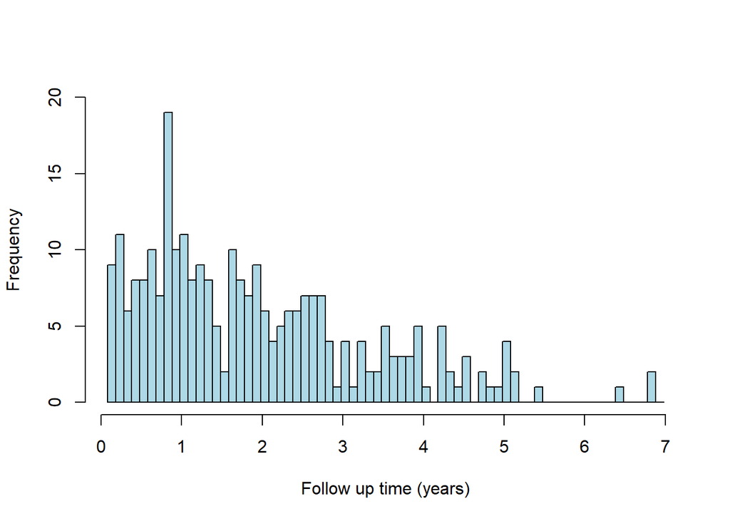

```r
# Histogram follow up time in years
hist((x = pSERG$followup_time_years), xlab="Follow up time (years)", main= NULL, seq(0.08, 7, 0.1), ylim=c(0,20), cex.axis=1, freq=TRUE, col="lightblue")
```

## Demographics. Description of the entire population and its characteristics.

The main objective in this block of code is: 1) present the main demographic and clinical characteristics of the entire cohort (table 1).

```r
# Age
gdata::nobs(pSERG$ageyears)
```

```
## [1] 276
```

```r
summary(pSERG$ageyears)
```

```
##     Min.  1st Qu.   Median     Mean  3rd Qu.     Max.
##  0.08333  1.16667  4.20833  5.61088  8.84792 20.74167
```

```r
sd(pSERG$ageyears)
```

```
## [1] 5.103899
```

```r
# Sex
CrossTable(pSERG$SEX)
```

```
##
##
##    Cell Contents
## |-------------------------|
## |                       N |
## |         N / Table Total |
## |-------------------------|
##
##
## Total Observations in Table:  276
##
##
##           |         0 |         1 |
##           |-----------|-----------|
##           |       120 |       156 |
##           |     0.435 |     0.565 |
##           |-----------|-----------|
##
##
##
##
```

```r
# Race
CrossTable(pSERG$RACE)
```

```
##
##
##    Cell Contents
## |-------------------------|
## |                       N |
## |         N / Table Total |
## |-------------------------|
##
##
## Total Observations in Table:  276
##
##
##                                     |       american_indian_alaska_native |                              arabic |                               asian |           black_or_african_american | native_hawaiian_or_pacific_islander |
##                                     |-------------------------------------|-------------------------------------|-------------------------------------|-------------------------------------|-------------------------------------|
##                                     |                                   1 |                                   8 |                                  12 |                                  50 |                                   1 |
##                                     |                               0.004 |                               0.029 |                               0.043 |                               0.181 |                               0.004 |
##                                     |-------------------------------------|-------------------------------------|-------------------------------------|-------------------------------------|-------------------------------------|
##
##
##                                     |                        not_reported |                             unknown |                               white |
##                                     |-------------------------------------|-------------------------------------|-------------------------------------|
##                                     |                                  11 |                                  13 |                                 180 |
##                                     |                               0.040 |                               0.047 |                               0.652 |
##                                     |-------------------------------------|-------------------------------------|-------------------------------------|
##
##
##
##
```

```r
# Ethnicity
CrossTable(pSERG$ETHNICITY)
```

```
##
##
##    Cell Contents
## |-------------------------|
## |                       N |
## |         N / Table Total |
## |-------------------------|
##
##
## Total Observations in Table:  276
##
##
##                        |     hispanic_or_latino | not_hispanic_or_latino |           not_reported |                unknown |
##                        |------------------------|------------------------|------------------------|------------------------|
##                        |                     47 |                    202 |                     22 |                      5 |
##                        |                  0.170 |                  0.732 |                  0.080 |                  0.018 |
##                        |------------------------|------------------------|------------------------|------------------------|
##
##
##
##
```

```r
# Type of status epilepticus
CrossTable(pSERG$TYPESTATUSint)
```

```
##
##
##    Cell Contents
## |-------------------------|
## |                       N |
## |         N / Table Total |
## |-------------------------|
##
##
## Total Observations in Table:  276
##
##
##           |         0 |         1 |
##           |-----------|-----------|
##           |        79 |       197 |
##           |     0.286 |     0.714 |
##           |-----------|-----------|
##
##
##
##
```

```r
# Etiology
CrossTable(pSERG$ETIOLOGY)
```

```
##
##
##    Cell Contents
## |-------------------------|
## |                       N |
## |         N / Table Total |
## |-------------------------|
##
##
## Total Observations in Table:  276
##
##
##            |    genetic |  metabolic |      other | structural |    unknown |
##            |------------|------------|------------|------------|------------|
##            |         58 |         10 |         38 |         76 |         94 |
##            |      0.210 |      0.036 |      0.138 |      0.275 |      0.341 |
##            |------------|------------|------------|------------|------------|
##
##
##
##
```

```r
# Developmental Delay
CrossTable(pSERG$delay)
```

```
##
##
##    Cell Contents
## |-------------------------|
## |                       N |
## |         N / Table Total |
## |-------------------------|
##
##
## Total Observations in Table:  276
##
##
##           |         0 |         1 |
##           |-----------|-----------|
##           |       123 |       153 |
##           |     0.446 |     0.554 |
##           |-----------|-----------|
##
##
##
##
```

```r
# Prior epilepsy
CrossTable(pSERG$epi)
```

```
##
##
##    Cell Contents
## |-------------------------|
## |                       N |
## |         N / Table Total |
## |-------------------------|
##
##
## Total Observations in Table:  276
##
##
##           |         0 |         1 |
##           |-----------|-----------|
##           |       137 |       139 |
##           |     0.496 |     0.504 |
##           |-----------|-----------|
##
##
##
##
```

```r
# Status
CrossTable(pSERG$status)
```

```
##
##
##    Cell Contents
## |-------------------------|
## |                       N |
## |         N / Table Total |
## |-------------------------|
##
##
## Total Observations in Table:  276
##
##
##           |         0 |         1 |
##           |-----------|-----------|
##           |       225 |        51 |
##           |     0.815 |     0.185 |
##           |-----------|-----------|
##
##
##
##
```

```r
# Palsy
CrossTable(pSERG$cerebral_palsy)
```

```
##
##
##    Cell Contents
## |-------------------------|
## |                       N |
## |         N / Table Total |
## |-------------------------|
##
##
## Total Observations in Table:  276
##
##
##           |         0 |         1 |
##           |-----------|-----------|
##           |       247 |        29 |
##           |     0.895 |     0.105 |
##           |-----------|-----------|
##
##
##
##
```

```r
# None
CrossTable(pSERG$none)
```

```
##
##
##    Cell Contents
## |-------------------------|
## |                       N |
## |         N / Table Total |
## |-------------------------|
##
##
## Total Observations in Table:  276
##
##
##           |         0 |         1 |
##           |-----------|-----------|
##           |       185 |        91 |
##           |     0.670 |     0.330 |
##           |-----------|-----------|
##
##
##
##
```

```r
# Febrile
CrossTable(pSERG$febrile)
```

```
##
##
##    Cell Contents
## |-------------------------|
## |                       N |
## |         N / Table Total |
## |-------------------------|
##
##
## Total Observations in Table:  276
##
##
##           |         0 |         1 |
##           |-----------|-----------|
##           |       243 |        33 |
##           |     0.880 |     0.120 |
##           |-----------|-----------|
##
##
##
##
```

```r
# Hospital onset
CrossTable(pSERG$HOSPITALONSETyes)
```

```
##
##
##    Cell Contents
## |-------------------------|
## |                       N |
## |         N / Table Total |
## |-------------------------|
##
##
## Total Observations in Table:  276
##
##
##           |         0 |         1 |
##           |-----------|-----------|
##           |       179 |        97 |
##           |     0.649 |     0.351 |
##           |-----------|-----------|
##
##
##
##
```

```r
# Use of CI
CrossTable(pSERG$CI)
```

```
##
##
##    Cell Contents
## |-------------------------|
## |                       N |
## |         N / Table Total |
## |-------------------------|
##
##
## Total Observations in Table:  276
##
##
##           |         0 |         1 |
##           |-----------|-----------|
##           |       126 |       150 |
##           |     0.457 |     0.543 |
##           |-----------|-----------|
##
##
##
##
```

## Subpopulation of patients with normal development

```r
# Create subset with only patients with normal development
pSERGnd <- subset(pSERG, pSERG$delay==0)
dim(pSERGnd)
```

```
## [1]  123 1603
```

```r
# EEG monitoring
CrossTable(pSERGnd$EEG_DONE)
```

```
##
##
##    Cell Contents
## |-------------------------|
## |                       N |
## |         N / Table Total |
## |-------------------------|
##
##
## Total Observations in Table:  123
##
##
##           |           |        no |       yes |
##           |-----------|-----------|-----------|
##           |        58 |         7 |        58 |
##           |     0.472 |     0.057 |     0.472 |
##           |-----------|-----------|-----------|
##
##
##
##
```

```r
pSERGnd <- pSERGnd[which(!(pSERGnd$EEG_DONE=="no")),]
dim(pSERGnd)
```

```
## [1]  116 1603
```

```r
# Summary of follow up time in years
summary(pSERGnd$followup_time_years)
```

```
##    Min. 1st Qu.  Median    Mean 3rd Qu.    Max.
## 0.08493 0.87397 1.84658 2.00475 2.72123 6.86575
```

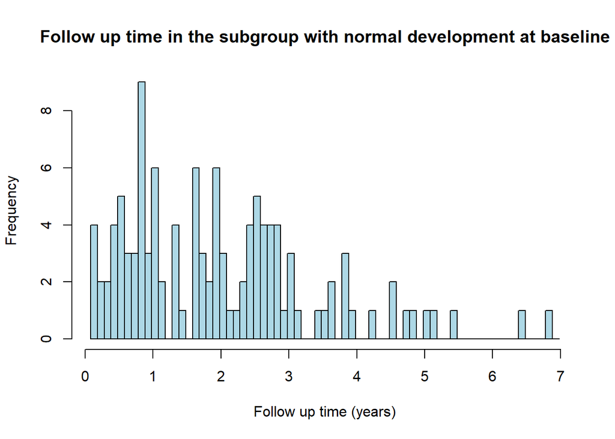

```r
# Histogram follow up time
hist((x = pSERGnd$followup_time_years), xlab="Follow up time (years)", seq(0.08, 7, 0.1), cex.axis=1, main= "Follow up time in the subgroup with normal development at baseline", freq=TRUE, col="lightblue")
```

## Demographics. Description of the patient population (2) and its characteristics.

The main objective in this block of code is: 1) present the main demographic and clinical characteristics of the sample with normal development (table 1).

```r
# Age
gdata::nobs(pSERGnd$ageyears)
```

```
## [1] 116
```

```r
summary(pSERGnd$ageyears)
```

```
##    Min. 1st Qu.  Median    Mean 3rd Qu.    Max.
##  0.1250  0.8333  3.0069  5.0744  8.8542 19.3058
```

```r
sd(pSERGnd$ageyears)
```

```
## [1] 5.145393
```

```r
# Sex
CrossTable(pSERGnd$SEX)
```

```
##
##
##    Cell Contents
## |-------------------------|
## |                       N |
## |         N / Table Total |
## |-------------------------|
##
##
## Total Observations in Table:  116
##
##
##           |         0 |         1 |
##           |-----------|-----------|
##           |        50 |        66 |
##           |     0.431 |     0.569 |
##           |-----------|-----------|
##
##
##
##
```

```r
# Race
CrossTable(pSERGnd$RACE)
```

```
##
##
##    Cell Contents
## |-------------------------|
## |                       N |
## |         N / Table Total |
## |-------------------------|
##
##
## Total Observations in Table:  116
##
##
##                           |                    arabic |                     asian | black_or_african_american |              not_reported |                   unknown |
##                           |---------------------------|---------------------------|---------------------------|---------------------------|---------------------------|
##                           |                         1 |                         6 |                        29 |                         5 |                         6 |
##                           |                     0.009 |                     0.052 |                     0.250 |                     0.043 |                     0.052 |
##                           |---------------------------|---------------------------|---------------------------|---------------------------|---------------------------|
##
##
##                           |                     white |
##                           |---------------------------|
##                           |                        69 |
##                           |                     0.595 |
##                           |---------------------------|
##
##
##
##
```

```r
# Ethnicity
CrossTable(pSERGnd$ETHNICITY)
```

```
##
##
##    Cell Contents
## |-------------------------|
## |                       N |
## |         N / Table Total |
## |-------------------------|
##
##
## Total Observations in Table:  116
##
##
##                        |     hispanic_or_latino | not_hispanic_or_latino |           not_reported |                unknown |
##                        |------------------------|------------------------|------------------------|------------------------|
##                        |                     16 |                     85 |                     13 |                      2 |
##                        |                  0.138 |                  0.733 |                  0.112 |                  0.017 |
##                        |------------------------|------------------------|------------------------|------------------------|
##
##
##
##
```

```r
# Type of status epilepticus
CrossTable(pSERGnd$TYPESTATUSint)
```

```
##
##
##    Cell Contents
## |-------------------------|
## |                       N |
## |         N / Table Total |
## |-------------------------|
##
##
## Total Observations in Table:  116
##
##
##           |         0 |         1 |
##           |-----------|-----------|
##           |        27 |        89 |
##           |     0.233 |     0.767 |
##           |-----------|-----------|
##
##
##
##
```

```r
# Etiology
CrossTable(pSERGnd$ETIOLOGY)
```

```
##
##
##    Cell Contents
## |-------------------------|
## |                       N |
## |         N / Table Total |
## |-------------------------|
##
##
## Total Observations in Table:  116
##
##
##            |    genetic |  metabolic |      other | structural |    unknown |
##            |------------|------------|------------|------------|------------|
##            |          8 |          6 |         29 |         33 |         40 |
##            |      0.069 |      0.052 |      0.250 |      0.284 |      0.345 |
##            |------------|------------|------------|------------|------------|
##
##
##
##
```

```r
# Prior epilepsy
CrossTable(pSERGnd$epi)
```

```
##
##
##    Cell Contents
## |-------------------------|
## |                       N |
## |         N / Table Total |
## |-------------------------|
##
##
## Total Observations in Table:  116
##
##
##           |         0 |         1 |
##           |-----------|-----------|
##           |        95 |        21 |
##           |     0.819 |     0.181 |
##           |-----------|-----------|
##
##
##
##
```

```r
# Status
CrossTable(pSERGnd$status)
```

```
##
##
##    Cell Contents
## |-------------------------|
## |                       N |
## |         N / Table Total |
## |-------------------------|
##
##
## Total Observations in Table:  116
##
##
##           |         0 |         1 |
##           |-----------|-----------|
##           |       112 |         4 |
##           |     0.966 |     0.034 |
##           |-----------|-----------|
##
##
##
##
```

```r
# Palsy
table(pSERGnd$cerebral_palsy)
```

```
##
##   0
## 116
```

```r
# None
CrossTable(pSERGnd$none)
```

```
##
##
##    Cell Contents
## |-------------------------|
## |                       N |
## |         N / Table Total |
## |-------------------------|
##
##
## Total Observations in Table:  116
##
##
##           |         0 |         1 |
##           |-----------|-----------|
##           |        29 |        87 |
##           |     0.250 |     0.750 |
##           |-----------|-----------|
##
##
##
##
```

```r
# Febrile
CrossTable(pSERGnd$febrile)
```

```
##
##
##    Cell Contents
## |-------------------------|
## |                       N |
## |         N / Table Total |
## |-------------------------|
##
##
## Total Observations in Table:  116
##
##
##           |         0 |         1 |
##           |-----------|-----------|
##           |       103 |        13 |
##           |     0.888 |     0.112 |
##           |-----------|-----------|
##
##
##
##
```

```r
# Hospital onset
CrossTable(pSERGnd$HOSPITALONSETyes)
```

```
##
##
##    Cell Contents
## |-------------------------|
## |                       N |
## |         N / Table Total |
## |-------------------------|
##
##
## Total Observations in Table:  116
##
##
##           |         0 |         1 |
##           |-----------|-----------|
##           |        62 |        54 |
##           |     0.534 |     0.466 |
##           |-----------|-----------|
##
##
##
##
```

##AIM 1. Clinical outcomes

# Long-term mortality (after hospital discharge and >30 days after SE onset)

The main objectives in this block of code are: 1) create variable for patients who died during follow up, 2) present causes of death in those patients and patients who die from SUDEP

```r
# Create variable death at follow up
CrossTable(pSERG$FU_ALIVE)
```

```
##
##
##    Cell Contents
## |-------------------------|
## |                       N |
## |         N / Table Total |
## |-------------------------|
##
##
## Total Observations in Table:  276
##
##
##           |        no |       yes |
##           |-----------|-----------|
##           |        15 |       261 |
##           |     0.054 |     0.946 |
##           |-----------|-----------|
##
##
##
##
```

```r
pSERG$fu_death <- ifelse(pSERG$FU_ALIVE == "no", 1, 0)
CrossTable(pSERG$fu_death)
```

```
##
##
##    Cell Contents
## |-------------------------|
## |                       N |
## |         N / Table Total |
## |-------------------------|
##
##
## Total Observations in Table:  276
##
##
##           |         0 |         1 |
##           |-----------|-----------|
##           |       261 |        15 |
##           |     0.946 |     0.054 |
##           |-----------|-----------|
##
##
##
##
```

```r
# Tabulate the lenght of the follow up period in patients who died at follow up
summary(pSERG[which(pSERG$fu_death==1), ]$followup_time_years)
```

```
##    Min. 1st Qu.  Median    Mean 3rd Qu.    Max.
##  0.1425  0.3877  0.6247  1.1978  2.0849  3.4932
```

```r
summary(pSERG[which(pSERG$fu_death==1), ]$followup_time_months)
```

```
##    Min. 1st Qu.  Median    Mean 3rd Qu.    Max.
##   1.733   4.717   7.600  14.573  25.367  42.500
```

```r
# Etiology at RSE of patients who died
CrossTable(pSERG[which(pSERG$fu_death==1), ]$ETIOLOGY)
```

```
##
##
##    Cell Contents
## |-------------------------|
## |                       N |
## |         N / Table Total |
## |-------------------------|
##
##
## Total Observations in Table:  15
##
##
##            |    genetic |      other | structural |    unknown |
##            |------------|------------|------------|------------|
##            |          8 |          1 |          5 |          1 |
##            |      0.533 |      0.067 |      0.333 |      0.067 |
##            |------------|------------|------------|------------|
##
##
##
##
```

```r
pSERG[which(pSERG$fu_death==1), ]$ETIOLOGY
```

```
##  [1] structural genetic    structural structural structural unknown
##  [7] genetic    structural genetic    other      genetic    genetic
## [13] genetic    genetic    genetic
## Levels:  genetic metabolic other structural unknown
```

```r
pSERG[which(pSERG$fu_death==1 & pSERG$ETIOLOGY=="structural"), ]$STRUCTURAL
```

```
## [1] acute  acute  acute  remote remote
## Levels:  acute not_applicable remote
```

```r
# Past neurological history at RSE of patients who died
CrossTable(pSERG[which(pSERG$fu_death==1), ]$PAST)
```

```
##
##
##    Cell Contents
## |-------------------------|
## |                       N |
## |         N / Table Total |
## |-------------------------|
##
##
## Total Observations in Table:  15
##
##
##           |     delay | epi,delay |      none |
##           |-----------|-----------|-----------|
##           |         2 |         5 |         8 |
##           |     0.133 |     0.333 |     0.533 |
##           |-----------|-----------|-----------|
##
##
##
##
```

```r
pSERG[which(pSERG$fu_death==1), ]$PAST
```

```
##  [1] none      delay     none      none      none      none      epi,delay
##  [8] epi,delay epi,delay none      epi,delay none      epi,delay none
## [15] delay
## 29 Levels:  cerebral_palsy ... status
```

```r
# Tabulate cause of death
pSERG[which(pSERG$fu_death == 1), ]$FU_CAUSE_DEATH
```

```
##  [1] SUDEP
##  [2] GSD Type 1 exacerbation in setting of illness
##  [3] Malignant pinealoma (brian tumor)
##  [4] Complications of DiGeorge Syndrome
##  [5] Sepsis
##  [6] Complications with end stage renal disease/Cardiac Arrest
##  [7] SUDEP
##  [8] Progression of mitochondrial disorder, acute liver failure, progressive anasarca, withdrawal of Life-Sustaining Treatment-Ventilator
##  [9] Complications due to MERFF, refractory epilespy and aspiration pneumonia
## [10] respiratory failure, Wiscott-Aldrich Syndrome
## [11] respiratory failure secondary to polG mutation
## [12] unknown
## [13]
## [14] Drowning / submersion
## [15] Liver failure in mitochondrial disease context
## 36 Levels:  anephric with end stae renal failure  ... Withdrawal of care in ICU secondary to DNM1L mutation and ongoing RSE
```

```r
# Create variable death of SUDEP
pSERG$fu_sudep <- ifelse(pSERG$FU_SUDEP == "yes", 1, 0)

# Tabulate death of SUDEP
CrossTable(pSERG[which(pSERG$fu_death == 1), ]$fu_sudep)
```

```
##
##
##    Cell Contents
## |-------------------------|
## |                       N |
## |         N / Table Total |
## |-------------------------|
##
##
## Total Observations in Table:  15
##
##
##           |         0 |         1 |
##           |-----------|-----------|
##           |        13 |         2 |
##           |     0.867 |     0.133 |
##           |-----------|-----------|
##
##
##
##
```

```r
# Past medical history of patients who died of SUDEP
pSERG[which(pSERG$fu_sudep == 1), ]$PAST
```

```
## [1] none      epi,delay
## 29 Levels:  cerebral_palsy ... status
```

```r
# ASM in patients who died of SUDEP
pSERG[which(pSERG$fu_sudep == 1), ]$FU_AEDS
```

```
## [1] yes yes
## Levels:  no yes
```

```r
pSERG[which(pSERG$fu_sudep == 1), ]$FU_AEDS_NUMBER
```

```
## [1] 4 3
## 28 Levels:  0 1 1-2 1 - LVT (20 mg/kg/d) ... Was on 1, then lost to follow-up
```

```r
pSERG[which(pSERG$fu_sudep == 1), ]$FU_RESCUE
```

```
## [1] yes yes
## Levels:  no unknown yes
```

# Prior epilepsy and long-term outcomes

The main objectives in this block of code are: 1) create variable for subsequent seizures at follow up, excluding patients with missing data, 2) relate the variable prior epilepsy and subsequent seizures at follow up (univariate analysis)

```r
#Tabulate subsequent seizures after SE
CrossTable(pSERG$FU_SEIZURE)
```

```
##
##
##    Cell Contents
## |-------------------------|
## |                       N |
## |         N / Table Total |
## |-------------------------|
##
##
## Total Observations in Table:  276
##
##
##           |           |        no |   unknown |       yes |
##           |-----------|-----------|-----------|-----------|
##           |        12 |        92 |         6 |       166 |
##           |     0.043 |     0.333 |     0.022 |     0.601 |
##           |-----------|-----------|-----------|-----------|
##
##
##
##
```

```r
pSERG$FU_SEIZURE[pSERG$FU_SEIZURE == ""] <- NA
CrossTable(is.na(pSERG$FU_SEIZURE))
```

```
##
##
##    Cell Contents
## |-------------------------|
## |                       N |
## |         N / Table Total |
## |-------------------------|
##
##
## Total Observations in Table:  276
##
##
##           |     FALSE |      TRUE |
##           |-----------|-----------|
##           |       264 |        12 |
##           |     0.957 |     0.043 |
##           |-----------|-----------|
##
##
##
##
```

```r
#Create variable subsequent seizures after SE
pSERG$fu_seizure[is.na(pSERG$FU_SEIZURE) == FALSE & pSERG$FU_SEIZURE == "yes"] <- 1
pSERG$fu_seizure[is.na(pSERG$FU_SEIZURE) == FALSE & (pSERG$FU_SEIZURE == "no" | pSERG$FU_SEIZURE == "unknown")] <- 0
CrossTable(pSERG$fu_seizure)
```

```
##
##
##    Cell Contents
## |-------------------------|
## |                       N |
## |         N / Table Total |
## |-------------------------|
##
##
## Total Observations in Table:  264
##
##
##           |         0 |         1 |
##           |-----------|-----------|
##           |        98 |       166 |
##           |     0.371 |     0.629 |
##           |-----------|-----------|
##
##
##
##
```

```r
# Subsequent seizures and prior epilepsy CrossTable(pSERGnd[pSERGnd$badgose4.8 == 0, ]$epi)
CrossTable(pSERG$epi, pSERG$fu_seizure)
```

```
##
##
##    Cell Contents
## |-------------------------|
## |                       N |
## | Chi-square contribution |
## |           N / Row Total |
## |           N / Col Total |
## |         N / Table Total |
## |-------------------------|
##
##
## Total Observations in Table:  264
##
##
##              | pSERG$fu_seizure
##    pSERG$epi |         0 |         1 | Row Total |
## -------------|-----------|-----------|-----------|
##            0 |        65 |        65 |       130 |
##              |     5.809 |     3.429 |           |
##              |     0.500 |     0.500 |     0.492 |
##              |     0.663 |     0.392 |           |
##              |     0.246 |     0.246 |           |
## -------------|-----------|-----------|-----------|
##            1 |        33 |       101 |       134 |
##              |     5.635 |     3.327 |           |
##              |     0.246 |     0.754 |     0.508 |
##              |     0.337 |     0.608 |           |
##              |     0.125 |     0.383 |           |
## -------------|-----------|-----------|-----------|
## Column Total |        98 |       166 |       264 |
##              |     0.371 |     0.629 |           |
## -------------|-----------|-----------|-----------|
##
##
```

```r
CrossTable(pSERG[pSERG$epi == 1, ]$fu_seizure)
```

```
##
##
##    Cell Contents
## |-------------------------|
## |                       N |
## |         N / Table Total |
## |-------------------------|
##
##
## Total Observations in Table:  134
##
##
##           |         0 |         1 |
##           |-----------|-----------|
##           |        33 |       101 |
##           |     0.246 |     0.754 |
##           |-----------|-----------|
##
##
##
##
```

```r
CrossTable(pSERG[pSERG$epi == 0, ]$fu_seizure)
```

```
##
##
##    Cell Contents
## |-------------------------|
## |                       N |
## |         N / Table Total |
## |-------------------------|
##
##
## Total Observations in Table:  130
##
##
##           |         0 |         1 |
##           |-----------|-----------|
##           |        65 |        65 |
##           |     0.500 |     0.500 |
##           |-----------|-----------|
##
##
##
##
```

```r
# Univariate analysis: prior epilepsy and subsequent seizures (Fisher's exact test)
fisher.test(table(pSERG$epi, pSERG$fu_seizure))
```

```
##
##  Fisher's Exact Test for Count Data
##
## data:  table(pSERG$epi, pSERG$fu_seizure)
## p-value = 2.403e-05
## alternative hypothesis: true odds ratio is not equal to 1
## 95 percent confidence interval:
##  1.760146 5.349010
## sample estimates:
## odds ratio
##   3.047079
```

```r
# Subsequent seizures and mortality
CrossTable(pSERG$fu_death, pSERG$FU_SEIZURE)
```

```
##
##
##    Cell Contents
## |-------------------------|
## |                       N |
## | Chi-square contribution |
## |           N / Row Total |
## |           N / Col Total |
## |         N / Table Total |
## |-------------------------|
##
##
## Total Observations in Table:  264
##
##
##                | pSERG$FU_SEIZURE
## pSERG$fu_death |        no |   unknown |       yes | Row Total |
## ---------------|-----------|-----------|-----------|-----------|
##              0 |        88 |         5 |       159 |       252 |
##                |     0.000 |     0.092 |     0.002 |           |
##                |     0.349 |     0.020 |     0.631 |     0.955 |
##                |     0.957 |     0.833 |     0.958 |           |
##                |     0.333 |     0.019 |     0.602 |           |
## ---------------|-----------|-----------|-----------|-----------|
##              1 |         4 |         1 |         7 |        12 |
##                |     0.008 |     1.939 |     0.039 |           |
##                |     0.333 |     0.083 |     0.583 |     0.045 |
##                |     0.043 |     0.167 |     0.042 |           |
##                |     0.015 |     0.004 |     0.027 |           |
## ---------------|-----------|-----------|-----------|-----------|
##   Column Total |        92 |         6 |       166 |       264 |
##                |     0.348 |     0.023 |     0.629 |           |
## ---------------|-----------|-----------|-----------|-----------|
##
##
```

```r
pSERG[which(pSERG$fu_death==1), ]$FU_SEIZURE
```

```
##  [1] unknown yes     yes     no      no      yes     yes     yes     no
## [10] no      yes     <NA>    <NA>    yes     <NA>
## Levels:  no unknown yes
```

# Treatment with AEDs or other treatments at follow-up

The main objectives in this block of code are: 1) create variable for patients who receive AEDs at follow up, excluding patients with missing data, 2) relate the variable prior epilepsy and subsequent seizures at follow up with AED treatment at follow up (univariate analysis), 3) Summarize number of AEDs received at follow up, relate it to the presence of prior epilepsy and decribe other treatments at follow up.

```r
# Tabulate AEDs at follow up
CrossTable(pSERG$FU_AEDS)
```

```
##
##
##    Cell Contents
## |-------------------------|
## |                       N |
## |         N / Table Total |
## |-------------------------|
##
##
## Total Observations in Table:  276
##
##
##           |           |        no |       yes |
##           |-----------|-----------|-----------|
##           |        11 |        30 |       235 |
##           |     0.040 |     0.109 |     0.851 |
##           |-----------|-----------|-----------|
##
##
##
##
```

```r
pSERG$FU_AEDS[pSERG$FU_AEDS == ""] <- NA
CrossTable(is.na(pSERG$FU_AEDS))
```

```
##
##
##    Cell Contents
## |-------------------------|
## |                       N |
## |         N / Table Total |
## |-------------------------|
##
##
## Total Observations in Table:  276
##
##
##           |     FALSE |      TRUE |
##           |-----------|-----------|
##           |       265 |        11 |
##           |     0.960 |     0.040 |
##           |-----------|-----------|
##
##
##
##
```

```r
#Create variable AEDS at follow up
pSERG$fu_aeds[is.na(pSERG$FU_AEDS) == FALSE & pSERG$FU_AEDS == "yes"] <- 1
pSERG$fu_aeds[is.na(pSERG$FU_AEDS) == FALSE & (pSERG$FU_AEDS == "no" | pSERG$FU_AEDS == "unknown")] <- 0
CrossTable(pSERG$fu_aeds)
```

```
##
##
##    Cell Contents
## |-------------------------|
## |                       N |
## |         N / Table Total |
## |-------------------------|
##
##
## Total Observations in Table:  265
##
##
##           |         0 |         1 |
##           |-----------|-----------|
##           |        30 |       235 |
##           |     0.113 |     0.887 |
##           |-----------|-----------|
##
##
##
##
```

```r
# Prior epilepsy and AEDs at follow up
CrossTable(pSERG$epi, pSERG$fu_aeds)
```

```
##
##
##    Cell Contents
## |-------------------------|
## |                       N |
## | Chi-square contribution |
## |           N / Row Total |
## |           N / Col Total |
## |         N / Table Total |
## |-------------------------|
##
##
## Total Observations in Table:  265
##
##
##              | pSERG$fu_aeds
##    pSERG$epi |         0 |         1 | Row Total |
## -------------|-----------|-----------|-----------|
##            0 |        27 |       102 |       129 |
##              |    10.522 |     1.343 |           |
##              |     0.209 |     0.791 |     0.487 |
##              |     0.900 |     0.434 |           |
##              |     0.102 |     0.385 |           |
## -------------|-----------|-----------|-----------|
##            1 |         3 |       133 |       136 |
##              |     9.981 |     1.274 |           |
##              |     0.022 |     0.978 |     0.513 |
##              |     0.100 |     0.566 |           |
##              |     0.011 |     0.502 |           |
## -------------|-----------|-----------|-----------|
## Column Total |        30 |       235 |       265 |
##              |     0.113 |     0.887 |           |
## -------------|-----------|-----------|-----------|
##
##
```

```r
CrossTable(pSERG[pSERG$epi == 1, ]$fu_aeds)
```

```
##
##
##    Cell Contents
## |-------------------------|
## |                       N |
## |         N / Table Total |
## |-------------------------|
##
##
## Total Observations in Table:  136
##
##
##           |         0 |         1 |
##           |-----------|-----------|
##           |         3 |       133 |
##           |     0.022 |     0.978 |
##           |-----------|-----------|
##
##
##
##
```

```r
CrossTable(pSERG[pSERG$epi == 0, ]$fu_aeds)
```

```
##
##
##    Cell Contents
## |-------------------------|
## |                       N |
## |         N / Table Total |
## |-------------------------|
##
##
## Total Observations in Table:  129
##
##
##           |         0 |         1 |
##           |-----------|-----------|
##           |        27 |       102 |
##           |     0.209 |     0.791 |
##           |-----------|-----------|
##
##
##
##
```

```r
# Univariate analysis: prior epilepsy and and AEDs at follow up (Fisher's exact test)
fisher.test(table(pSERG$epi, pSERG$fu_aeds))
```

```
##
##  Fisher's Exact Test for Count Data
##
## data:  table(pSERG$epi, pSERG$fu_aeds)
## p-value = 8.528e-07
## alternative hypothesis: true odds ratio is not equal to 1
## 95 percent confidence interval:
##   3.439038 61.665321
## sample estimates:
## odds ratio
##   11.64462
```

```r
# AEDs at follow up and subsequent seizures (in patients with no prior epilepsy)
CrossTable(pSERG[which(pSERG$epi==0), ]$fu_seizure, pSERG[which(pSERG$epi==0), ]$fu_aeds)
```

```
##
##
##    Cell Contents
## |-------------------------|
## |                       N |
## | Chi-square contribution |
## |           N / Row Total |
## |           N / Col Total |
## |         N / Table Total |
## |-------------------------|
##
##
## Total Observations in Table:  129
##
##
##                                           | pSERG[which(pSERG$epi == 0), ]$fu_aeds
## pSERG[which(pSERG$epi == 0), ]$fu_seizure |         0 |         1 | Row Total |
## ------------------------------------------|-----------|-----------|-----------|
##                                         0 |        24 |        40 |        64 |
##                                           |     8.395 |     2.222 |           |
##                                           |     0.375 |     0.625 |     0.496 |
##                                           |     0.889 |     0.392 |           |
##                                           |     0.186 |     0.310 |           |
## ------------------------------------------|-----------|-----------|-----------|
##                                         1 |         3 |        62 |        65 |
##                                           |     8.266 |     2.188 |           |
##                                           |     0.046 |     0.954 |     0.504 |
##                                           |     0.111 |     0.608 |           |
##                                           |     0.023 |     0.481 |           |
## ------------------------------------------|-----------|-----------|-----------|
##                              Column Total |        27 |       102 |       129 |
##                                           |     0.209 |     0.791 |           |
## ------------------------------------------|-----------|-----------|-----------|
##
##
```

```r
# Univariate analysis: AEDs at follow up and subsequent seizures (Fisher's exact test)
fisher.test(table(pSERG[which(pSERG$epi==0), ]$fu_seizure, pSERG[which(pSERG$epi==0), ]$fu_aeds))
```

```
##
##  Fisher's Exact Test for Count Data
##
## data:
## p-value = 2.778e-06
## alternative hypothesis: true odds ratio is not equal to 1
## 95 percent confidence interval:
##   3.37097 67.14336
## sample estimates:
## odds ratio
##   12.17079
```

```r
# Summarize number of AEDs at follow up
table(pSERG$FU_AEDS_NUMBER)
```

```
##
##                                                                     0
##                                 41                                  3
##                                  1                                1-2
##                                 72                                  1
##               1 - LVT (20 mg/kg/d) 1 + left functional hemispherotomy
##                                  1                                  1
##                                  2                                 2
##                                 47                                  0
##                 2 + Ketogenic diet                  2+ ketogenic diet
##                                  0                                  0
##                             2+ VNS                                  3
##                                  0                                 48
##                 3 + Ketogenic diet              3+ surgical resection
##                                  1                                  1
##                              3+VNS                                  4
##                                  1                                 27
##                                 4                             4+ keto
##                                  0                                  1
##                             4+ VNS                                  5
##                                  1                                 24
##                                  6                                  7
##                                  2                                  3
##                                  8                             Keppra
##                                  0                                  0
##                        Keppra only      Many, has seizures constantly
##                                  0                                  1
##                    one, lacosamide   Was on 1, then lost to follow-up
##                                  0                                  0
```

```r
pSERG$FU_AEDS_NUMBER <- as.character(as.factor(pSERG$FU_AEDS_NUMBER))
pSERG$FU_AEDS_NUMBER <- as.numeric(as.character(pSERG$FU_AEDS_NUMBER))
class(pSERG$FU_AEDS_NUMBER)
```

```
## [1] "numeric"
```

```r
table(is.na(pSERG$FU_AEDS_NUMBER))
```

```
##
## FALSE  TRUE
##   226    50
```

```r
CrossTable(pSERG$FU_AEDS_NUMBER)
```

```
##
##
##    Cell Contents
## |-------------------------|
## |                       N |
## |         N / Table Total |
## |-------------------------|
##
##
## Total Observations in Table:  226
##
##
##           |         0 |         1 |         2 |         3 |         4 |
##           |-----------|-----------|-----------|-----------|-----------|
##           |         3 |        72 |        47 |        48 |        27 |
##           |     0.013 |     0.319 |     0.208 |     0.212 |     0.119 |
##           |-----------|-----------|-----------|-----------|-----------|
##
##
##           |         5 |         6 |         7 |
##           |-----------|-----------|-----------|
##           |        24 |         2 |         3 |
##           |     0.106 |     0.009 |     0.013 |
##           |-----------|-----------|-----------|
##
##
##
##
```

```r
summary(pSERG$FU_AEDS_NUMBER)
```

```
##    Min. 1st Qu.  Median    Mean 3rd Qu.    Max.    NA's
##   0.000   1.000   2.000   2.527   3.000   7.000      50
```

```r
# Summarize number of AEDs at follow up if prior epilepsy
summary(pSERG[pSERG$epi == 1, ]$FU_AEDS_NUMBER)
```

```
##    Min. 1st Qu.  Median    Mean 3rd Qu.    Max.    NA's
##   0.000   2.000   3.000   2.929   4.000   7.000      12
```

```r
# Summarize number of AEDs at follow up if no prior epilepsy
summary(pSERG[pSERG$epi == 0, ]$FU_AEDS_NUMBER)
```

```
##    Min. 1st Qu.  Median    Mean 3rd Qu.    Max.    NA's
##    0.00    1.00    1.00    2.01    3.00    7.00      38
```

```r
# Univariate analysis: number of AEDs and prior epilepsy (Wilcoxon rank sum test)
wilcox.test(pSERG$FU_AEDS_NUMBER ~ pSERG$epi)
```

```
##
##  Wilcoxon rank sum test with continuity correction
##
## data:  pSERG$FU_AEDS_NUMBER by pSERG$epi
## W = 3863.5, p-value = 3.28e-07
## alternative hypothesis: true location shift is not equal to 0
```

#Prior SE or recurrent RSE and long-term outcomes The main objectives in this block of code are: 1) create variable for recurrent RSE at follow up, excluding patients with missing data, 2) relate the variable prior SE and recurrence of RSE at follow up (univariate analysis)

```r
# --- Prior SE
# Tabulate prior SE
CrossTable(pSERG$status)
```

```
##
##
##    Cell Contents
## |-------------------------|
## |                       N |
## |         N / Table Total |
## |-------------------------|
##
##
## Total Observations in Table:  276
##
##
##           |         0 |         1 |
##           |-----------|-----------|
##           |       225 |        51 |
##           |     0.815 |     0.185 |
##           |-----------|-----------|
##
##
##
##
```

```r
# --- Recurrent RSE
# Tabulate recurrent RSE
CrossTable(pSERG$FU_RSE)
```

```
##
##
##    Cell Contents
## |-------------------------|
## |                       N |
## |         N / Table Total |
## |-------------------------|
##
##
## Total Observations in Table:  276
##
##
##           |           |        no |   unknown |       yes |
##           |-----------|-----------|-----------|-----------|
##           |        15 |       210 |         7 |        44 |
##           |     0.054 |     0.761 |     0.025 |     0.159 |
##           |-----------|-----------|-----------|-----------|
##
##
##
##
```

```r
# Create variable recurrent SE at follow up
pSERG$FU_RSE[pSERG$FU_RSE == ""] <- NA
CrossTable(is.na(pSERG$FU_RSE))
```

```
##
##
##    Cell Contents
## |-------------------------|
## |                       N |
## |         N / Table Total |
## |-------------------------|
##
##
## Total Observations in Table:  276
##
##
##           |     FALSE |      TRUE |
##           |-----------|-----------|
##           |       261 |        15 |
##           |     0.946 |     0.054 |
##           |-----------|-----------|
##
##
##
##
```

```r
pSERG$fu_rse[is.na(pSERG$FU_RSE) == FALSE & pSERG$FU_RSE == "yes"] <- 1
pSERG$fu_rse[is.na(pSERG$FU_RSE) == FALSE & (pSERG$FU_RSE == "no" | pSERG$FU_RSE == "unknown")] <- 0

# Tabulate recurrent RSE at follow up
CrossTable(pSERG$fu_rse)
```

```
##
##
##    Cell Contents
## |-------------------------|
## |                       N |
## |         N / Table Total |
## |-------------------------|
##
##
## Total Observations in Table:  261
##
##
##           |         0 |         1 |
##           |-----------|-----------|
##           |       217 |        44 |
##           |     0.831 |     0.169 |
##           |-----------|-----------|
##
##
##
##
```

```r
#Tabulate recurrent RSE and prior SE
CrossTable(pSERG$fu_rse, pSERG$status)
```

```
##
##
##    Cell Contents
## |-------------------------|
## |                       N |
## | Chi-square contribution |
## |           N / Row Total |
## |           N / Col Total |
## |         N / Table Total |
## |-------------------------|
##
##
## Total Observations in Table:  261
##
##
##              | pSERG$status
## pSERG$fu_rse |         0 |         1 | Row Total |
## -------------|-----------|-----------|-----------|
##            0 |       182 |        35 |       217 |
##              |     0.187 |     0.809 |           |
##              |     0.839 |     0.161 |     0.831 |
##              |     0.858 |     0.714 |           |
##              |     0.697 |     0.134 |           |
## -------------|-----------|-----------|-----------|
##            1 |        30 |        14 |        44 |
##              |     0.922 |     3.988 |           |
##              |     0.682 |     0.318 |     0.169 |
##              |     0.142 |     0.286 |           |
##              |     0.115 |     0.054 |           |
## -------------|-----------|-----------|-----------|
## Column Total |       212 |        49 |       261 |
##              |     0.812 |     0.188 |           |
## -------------|-----------|-----------|-----------|
##
##
```

```r
CrossTable(pSERG[pSERG$status == 1, ]$fu_rse)
```

```
##
##
##    Cell Contents
## |-------------------------|
## |                       N |
## |         N / Table Total |
## |-------------------------|
##
##
## Total Observations in Table:  49
##
##
##           |         0 |         1 |
##           |-----------|-----------|
##           |        35 |        14 |
##           |     0.714 |     0.286 |
##           |-----------|-----------|
##
##
##
##
```

```r
CrossTable(pSERG[pSERG$status == 0, ]$fu_rse)
```

```
##
##
##    Cell Contents
## |-------------------------|
## |                       N |
## |         N / Table Total |
## |-------------------------|
##
##
## Total Observations in Table:  212
##
##
##           |         0 |         1 |
##           |-----------|-----------|
##           |       182 |        30 |
##           |     0.858 |     0.142 |
##           |-----------|-----------|
##
##
##
##
```

```r
# Univariate analysis: prior SE and and recurrece of RSE at follow up (Fisher's exact test)
fisher.test(table(pSERG$status, pSERG$fu_rse))
```

```
##
##  Fisher's Exact Test for Count Data
##
## data:  table(pSERG$status, pSERG$fu_rse)
## p-value = 0.02015
## alternative hypothesis: true odds ratio is not equal to 1
## 95 percent confidence interval:
##  1.071403 5.284059
## sample estimates:
## odds ratio
##   2.416779
```

```r
# Recurrent RSE and mortality
CrossTable(pSERG$fu_death, pSERG$FU_RSE)
```

```
##
##
##    Cell Contents
## |-------------------------|
## |                       N |
## | Chi-square contribution |
## |           N / Row Total |
## |           N / Col Total |
## |         N / Table Total |
## |-------------------------|
##
##
## Total Observations in Table:  261
##
##
##                | pSERG$FU_RSE
## pSERG$fu_death |        no |   unknown |       yes | Row Total |
## ---------------|-----------|-----------|-----------|-----------|
##              0 |       201 |         7 |        41 |       249 |
##                |     0.002 |     0.016 |     0.023 |           |
##                |     0.807 |     0.028 |     0.165 |     0.954 |
##                |     0.957 |     1.000 |     0.932 |           |
##                |     0.770 |     0.027 |     0.157 |           |
## ---------------|-----------|-----------|-----------|-----------|
##              1 |         9 |         0 |         3 |        12 |
##                |     0.044 |     0.322 |     0.472 |           |
##                |     0.750 |     0.000 |     0.250 |     0.046 |
##                |     0.043 |     0.000 |     0.068 |           |
##                |     0.034 |     0.000 |     0.011 |           |
## ---------------|-----------|-----------|-----------|-----------|
##   Column Total |       210 |         7 |        44 |       261 |
##                |     0.805 |     0.027 |     0.169 |           |
## ---------------|-----------|-----------|-----------|-----------|
##
##
```

```r
pSERG[which(pSERG$fu_death==1), ]$FU_RSE
```

```
##  [1] yes  no   yes  no   no   no   no   no   yes  no   no   <NA> <NA> no   <NA>
## Levels:  no unknown yes
```

#Rescue medication at follow up The main objectives in this block of code are: 1) create variable for rescue medication received up to follow up date, excluding patients with missing data, 2) relate the variable prior status epilepticus and rescue medication received at follow up (univariate analysis).

```r
# --- Rescue medication at follow up
# Tabulate rescue medication at follow up
CrossTable(pSERG$FU_RESCUE)
```

```
##
##
##    Cell Contents
## |-------------------------|
## |                       N |
## |         N / Table Total |
## |-------------------------|
##
##
## Total Observations in Table:  276
##
##
##           |           |        no |   unknown |       yes |
##           |-----------|-----------|-----------|-----------|
##           |        45 |       109 |         9 |       113 |
##           |     0.163 |     0.395 |     0.033 |     0.409 |
##           |-----------|-----------|-----------|-----------|
##
##
##
##
```

```r
# Create variable prior SE
pSERG$FU_RESCUE[pSERG$FU_RESCUE == ""] <- NA
CrossTable(is.na(pSERG$FU_RESCUE))
```

```
##
##
##    Cell Contents
## |-------------------------|
## |                       N |
## |         N / Table Total |
## |-------------------------|
##
##
## Total Observations in Table:  276
##
##
##           |     FALSE |      TRUE |
##           |-----------|-----------|
##           |       231 |        45 |
##           |     0.837 |     0.163 |
##           |-----------|-----------|
##
##
##
##
```

```r
pSERG$fu_rescue[is.na(pSERG$FU_RESCUE) == FALSE & pSERG$FU_RESCUE == "yes"] <- 1
pSERG$fu_rescue[is.na(pSERG$FU_RESCUE) == FALSE & (pSERG$FU_RESCUE == "no" | pSERG$FU_RESCUE == "unknown")] <- 0

# Tabulate rescue medication at follow up
CrossTable(pSERG$fu_rescue)
```

```
##
##
##    Cell Contents
## |-------------------------|
## |                       N |
## |         N / Table Total |
## |-------------------------|
##
##
## Total Observations in Table:  231
##
##
##           |         0 |         1 |
##           |-----------|-----------|
##           |       118 |       113 |
##           |     0.511 |     0.489 |
##           |-----------|-----------|
##
##
##
##
```

```r
# Univariate analysis: prior SE and and rescue medication at follow up (Fisher's exact test)
fisher.test(table(pSERG$status, pSERG$fu_rescue))
```

```
##
##  Fisher's Exact Test for Count Data
##
## data:  table(pSERG$status, pSERG$fu_rescue)
## p-value = 0.09868
## alternative hypothesis: true odds ratio is not equal to 1
## 95 percent confidence interval:
##  0.9032623 3.7666195
## sample estimates:
## odds ratio
##   1.825237
```

#Underlying SE etiology at follow up The main objectives in this block of code are: 1) create variables for different underlying etiologies according to follow up visits, 2) present the proportion of patients for each etiology excluding patients with missing data, 3) present the proportion of patients with unknown etiology at discharge and specific etiology at follow up

```r
# --- Etiology at follow up
# Tabulate etiology at follow up
CrossTable(pSERG$FU_ETIOLOGY)
```

```
##
##
##    Cell Contents
## |-------------------------|
## |                       N |
## |         N / Table Total |
## |-------------------------|
##
##
## Total Observations in Table:  276
##
##
##                            |                            |                    genetic |             genetic,immune |         genetic,infectious | genetic,infectious,unknown |
##                            |----------------------------|----------------------------|----------------------------|----------------------------|----------------------------|
##                            |                         20 |                         50 |                          1 |                          5 |                          1 |
##                            |                      0.072 |                      0.181 |                      0.004 |                      0.018 |                      0.004 |
##                            |----------------------------|----------------------------|----------------------------|----------------------------|----------------------------|
##
##
##                            |          genetic,metabolic |         genetic,structural | genetic,structural,unknown |            genetic,unknown |                     immune |
##                            |----------------------------|----------------------------|----------------------------|----------------------------|----------------------------|
##                            |                          3 |                         21 |                          2 |                          7 |                         12 |
##                            |                      0.011 |                      0.076 |                      0.007 |                      0.025 |                      0.043 |
##                            |----------------------------|----------------------------|----------------------------|----------------------------|----------------------------|
##
##
##                            |                 infectious |         infectious,unknown |                  metabolic |                 structural |      structural,infectious |
##                            |----------------------------|----------------------------|----------------------------|----------------------------|----------------------------|
##                            |                         19 |                          3 |                          1 |                         59 |                          4 |
##                            |                      0.069 |                      0.011 |                      0.004 |                      0.214 |                      0.014 |
##                            |----------------------------|----------------------------|----------------------------|----------------------------|----------------------------|
##
##
##                            |       structural,metabolic |         structural,unknown |                    unknown |
##                            |----------------------------|----------------------------|----------------------------|
##                            |                          1 |                          4 |                         63 |
##                            |                      0.004 |                      0.014 |                      0.228 |
##                            |----------------------------|----------------------------|----------------------------|
##
##
##
##
```

```r
# Identify not available etiology at follow up
pSERG$FU_ETIOLOGY[pSERG$FU_ETIOLOGY == ""] <- NA
CrossTable(is.na(pSERG$FU_ETIOLOGY))
```

```
##
##
##    Cell Contents
## |-------------------------|
## |                       N |
## |         N / Table Total |
## |-------------------------|
##
##
## Total Observations in Table:  276
##
##
##           |     FALSE |      TRUE |
##           |-----------|-----------|
##           |       256 |        20 |
##           |     0.928 |     0.072 |
##           |-----------|-----------|
##
##
##
##
```

```r
## Create variable for genetic etiology at follow up (summarize with one single etiology per patients considering the underlying etiology of patient with RSE)
pSERG$genetic_total[pSERG$FU_ETIOLOGY == "genetic" | pSERG$FU_ETIOLOGY == "genetic,immune"| pSERG$FU_ETIOLOGY == "genetic,infectious" | pSERG$FU_ETIOLOGY == "genetic,unknown" | pSERG$FU_ETIOLOGY == "genetic,infectious,unknown" | pSERG$FU_ETIOLOGY == "genetic,structural,unknown"] <- 1
pSERG$genetic_total[!(pSERG$FU_ETIOLOGY == "genetic" | pSERG$FU_ETIOLOGY == "genetic,immune"| pSERG$FU_ETIOLOGY == "genetic,infectious" | pSERG$FU_ETIOLOGY == "genetic,unknown" | pSERG$FU_ETIOLOGY == "genetic,infectious,unknown" | pSERG$FU_ETIOLOGY == "genetic,structural,unknown")] <- 0
CrossTable(pSERG[which(is.na(pSERG$FU_ETIOLOGY) == FALSE), ]$genetic_total)
```

```
##
##
##    Cell Contents
## |-------------------------|
## |                       N |
## |         N / Table Total |
## |-------------------------|
##
##
## Total Observations in Table:  256
##
##
##           |         0 |         1 |
##           |-----------|-----------|
##           |       190 |        66 |
##           |     0.742 |     0.258 |
##           |-----------|-----------|
##
##
##
##
```

```r
## Create variable for structural etiology at follow up (summarize with one single etiology per patients considering the underlying etiology of patient with RSE)
pSERG$structural_total[pSERG$FU_ETIOLOGY == "structural" | pSERG$FU_ETIOLOGY == "genetic,structural"] <- 1
pSERG$structural_total[!(pSERG$FU_ETIOLOGY == "structural" | pSERG$FU_ETIOLOGY == "genetic,structural")] <- 0
CrossTable(pSERG[which(is.na(pSERG$FU_ETIOLOGY) == FALSE), ]$structural_total)
```

```
##
##
##    Cell Contents
## |-------------------------|
## |                       N |
## |         N / Table Total |
## |-------------------------|
##
##
## Total Observations in Table:  256
##
##
##           |         0 |         1 |
##           |-----------|-----------|
##           |       176 |        80 |
##           |     0.688 |     0.312 |
##           |-----------|-----------|
##
##
##
##
```

```r
## Create variable for infectious etiology at follow up (summarize with one single etiology per patients considering the underlying etiology of patient with RSE)
pSERG$infectious_total[pSERG$FU_ETIOLOGY == "infectious" | pSERG$FU_ETIOLOGY == "structural,infectious" | pSERG$FU_ETIOLOGY == "infectious,unknown"] <- 1
pSERG$infectious_total[!(pSERG$FU_ETIOLOGY == "infectious" | pSERG$FU_ETIOLOGY == "structural,infectious" | pSERG$FU_ETIOLOGY == "infectious,unknown")] <- 0
CrossTable(pSERG[which(is.na(pSERG$FU_ETIOLOGY) == FALSE), ]$infectious_total)
```

```
##
##
##    Cell Contents
## |-------------------------|
## |                       N |
## |         N / Table Total |
## |-------------------------|
##
##
## Total Observations in Table:  256
##
##
##           |         0 |         1 |
##           |-----------|-----------|
##           |       230 |        26 |
##           |     0.898 |     0.102 |
##           |-----------|-----------|
##
##
##
##
```

```r
## Create variable for metabolic etiology at follow up (summarize with one single etiology per patients considering the underlying etiology of patient with RSE)
pSERG$metabolic_total[pSERG$FU_ETIOLOGY == "metabolic" | pSERG$FU_ETIOLOGY == "genetic,metabolic"| pSERG$FU_ETIOLOGY == "structural,metabolic"] <- 1
pSERG$metabolic_total[!(pSERG$FU_ETIOLOGY == "metabolic" | pSERG$FU_ETIOLOGY == "genetic,metabolic"| pSERG$FU_ETIOLOGY == "structural,metabolic")] <- 0
CrossTable(pSERG[which(is.na(pSERG$FU_ETIOLOGY) == FALSE), ]$metabolic_total)
```

```
##
##
##    Cell Contents
## |-------------------------|
## |                       N |
## |         N / Table Total |
## |-------------------------|
##
##
## Total Observations in Table:  256
##
##
##           |         0 |         1 |
##           |-----------|-----------|
##           |       251 |         5 |
##           |     0.980 |     0.020 |
##           |-----------|-----------|
##
##
##
##
```

```r
## Create variable for immune etiology at follow up
pSERG$immune_total[pSERG$FU_ETIOLOGY == "immune"] <- 1
pSERG$immune_total[!(pSERG$FU_ETIOLOGY == "immune")] <- 0
CrossTable(pSERG[which(is.na(pSERG$FU_ETIOLOGY) == FALSE), ]$immune_total)
```

```
##
##
##    Cell Contents
## |-------------------------|
## |                       N |
## |         N / Table Total |
## |-------------------------|
##
##
## Total Observations in Table:  256
##
##
##           |         0 |         1 |
##           |-----------|-----------|
##           |       244 |        12 |
##           |     0.953 |     0.047 |
##           |-----------|-----------|
##
##
##
##
```

```r
## Create variable for unknown etiology at follow up
pSERG$unknown_total[pSERG$FU_ETIOLOGY == "unknown"  | pSERG$FU_ETIOLOGY == "structural,unknown"] <- 1
pSERG$unknown_total[!(pSERG$FU_ETIOLOGY == "unknown" | pSERG$FU_ETIOLOGY == "structural,unknown")] <- 0
CrossTable(pSERG[which(is.na(pSERG$FU_ETIOLOGY) == FALSE), ]$unknown_total)
```

```
##
##
##    Cell Contents
## |-------------------------|
## |                       N |
## |         N / Table Total |
## |-------------------------|
##
##
## Total Observations in Table:  256
##
##
##           |         0 |         1 |
##           |-----------|-----------|
##           |       189 |        67 |
##           |     0.738 |     0.262 |
##           |-----------|-----------|
##
##
##
##
```

```r
# Create variable newly identified etiology to show patients with unknown etiology during admission for SE and etiology different to unknown at follow up
pSERG$fu_known_etiology <- NA
pSERG$fu_known_etiology[pSERG$genetic_total == 1 | pSERG$structural_total == 1 | pSERG$metabolic_total == 1 | pSERG$immune_total == 1 | pSERG$infectious_total == 1] <- 1
pSERG$fu_known_etiology[pSERG$unknown_total == 1] <- 0

# Tabulate diagnosed etiologies at follow up in patients with newly known etiology
CrossTable(pSERG$FU_ETIOLOGY, pSERG$unknown_etiology)
```

```
##
##
##    Cell Contents
## |-------------------------|
## |                       N |
## | Chi-square contribution |
## |           N / Row Total |
## |           N / Col Total |
## |         N / Table Total |
## |-------------------------|
##
##
## Total Observations in Table:  256
##
##
##                            | pSERG$unknown_etiology
##          pSERG$FU_ETIOLOGY |         0 |         1 | Row Total |
## ---------------------------|-----------|-----------|-----------|
##                    genetic |        40 |        10 |        50 |
##                            |     1.391 |     2.750 |           |
##                            |     0.800 |     0.200 |     0.195 |
##                            |     0.235 |     0.116 |           |
##                            |     0.156 |     0.039 |           |
## ---------------------------|-----------|-----------|-----------|
##             genetic,immune |         1 |         0 |         1 |
##                            |     0.170 |     0.336 |           |
##                            |     1.000 |     0.000 |     0.004 |
##                            |     0.006 |     0.000 |           |
##                            |     0.004 |     0.000 |           |
## ---------------------------|-----------|-----------|-----------|
##         genetic,infectious |         4 |         1 |         5 |
##                            |     0.139 |     0.275 |           |
##                            |     0.800 |     0.200 |     0.020 |
##                            |     0.024 |     0.012 |           |
##                            |     0.016 |     0.004 |           |
## ---------------------------|-----------|-----------|-----------|
## genetic,infectious,unknown |         1 |         0 |         1 |
##                            |     0.170 |     0.336 |           |
##                            |     1.000 |     0.000 |     0.004 |
##                            |     0.006 |     0.000 |           |
```

[output cut: 70 more lines]

```
##                            |     0.750 |     0.250 |     0.016 |
##                            |     0.018 |     0.012 |           |
##                            |     0.012 |     0.004 |           |
## ---------------------------|-----------|-----------|-----------|
##                    unknown |        18 |        45 |        63 |
##                            |    13.580 |    26.845 |           |
##                            |     0.286 |     0.714 |     0.246 |
##                            |     0.106 |     0.523 |           |
##                            |     0.070 |     0.176 |           |
## ---------------------------|-----------|-----------|-----------|
##               Column Total |       170 |        86 |       256 |
##                            |     0.664 |     0.336 |           |
## ---------------------------|-----------|-----------|-----------|
##
##
```

```r
# Tabulate patients with newly known etiology at FU
CrossTable(pSERG$fu_known_etiology, pSERG$unknown_etiology)
```

```
##
##
##    Cell Contents
## |-------------------------|
## |                       N |
## | Chi-square contribution |
## |           N / Row Total |
## |           N / Col Total |
## |         N / Table Total |
## |-------------------------|
##
##
## Total Observations in Table:  256
##
##
##                         | pSERG$unknown_etiology
## pSERG$fu_known_etiology |         0 |         1 | Row Total |
## ------------------------|-----------|-----------|-----------|
##                       0 |        21 |        46 |        67 |
##                         |    12.404 |    24.520 |           |
##                         |     0.313 |     0.687 |     0.262 |
##                         |     0.124 |     0.535 |           |
##                         |     0.082 |     0.180 |           |
## ------------------------|-----------|-----------|-----------|
##                       1 |       149 |        40 |       189 |
##                         |     4.397 |     8.692 |           |
##                         |     0.788 |     0.212 |     0.738 |
##                         |     0.876 |     0.465 |           |
##                         |     0.582 |     0.156 |           |
## ------------------------|-----------|-----------|-----------|
##            Column Total |       170 |        86 |       256 |
##                         |     0.664 |     0.336 |           |
## ------------------------|-----------|-----------|-----------|
##
##
```

```r
pSERG[which(pSERG$fu_known_etiology==1 & pSERG$unknown_etiology==1),]$FU_ETIOLOGY
```

```
##  [1] genetic,unknown            structural
##  [3] structural                 genetic
##  [5] genetic,unknown            immune
##  [7] genetic                    structural
##  [9] genetic,infectious         genetic,structural
## [11] genetic,unknown            infectious
## [13] genetic,unknown            infectious,unknown
## [15] genetic                    infectious
## [17] genetic,structural         genetic,structural
## [19] structural                 structural
## [21] immune                     genetic
## [23] genetic,unknown            genetic
## [25] genetic,structural,unknown metabolic
## [27] genetic                    genetic
## [29] immune                     immune
## [31] immune                     immune
## [33] immune                     immune
## [35] genetic                    infectious
## [37] genetic                    structural
## [39] genetic                    infectious
## 23 Levels:  genetic genetic,immune ... unknown
```

## AIM 2. Developmental outcomes.

#Primary outcome: New neurological deficit The main objectives in this block of code are: 1) create variables that represent the population we aim to study (presence or absence of new neurological deficit in previously normally developed children), 2) evaluate potential predictors of new neurological deficit choosen by scientific/clinical knowledge in univariate statistical analysis.

```r
# Tabulate complete data for new neurological deficit
pSERGnd$FU_NEWDEFICIT[pSERGnd$FU_NEWDEFICIT == ""] <- NA
CrossTable(is.na(pSERGnd$FU_NEWDEFICIT))
```

```
##
##
##    Cell Contents
## |-------------------------|
## |                       N |
## |         N / Table Total |
## |-------------------------|
##
##
## Total Observations in Table:  116
##
##
##           |     FALSE |      TRUE |
##           |-----------|-----------|
##           |       107 |         9 |
##           |     0.922 |     0.078 |
##           |-----------|-----------|
##
##
##
##
```

```r
# Create variable for new deficit
pSERGnd$newdeficit <- NA
pSERGnd$newdeficit[is.na(pSERGnd$FU_NEWDEFICIT) == FALSE & pSERGnd$FU_NEWDEFICIT == "yes"] <- 1
pSERGnd$newdeficit[is.na(pSERGnd$FU_NEWDEFICIT) == FALSE & (pSERGnd$FU_NEWDEFICIT == "no" | pSERGnd$FU_NEWDEFICIT == "unknown")] <- 0
CrossTable(pSERGnd$newdeficit)
```

```
##
##
##    Cell Contents
## |-------------------------|
## |                       N |
## |         N / Table Total |
## |-------------------------|
##
##
## Total Observations in Table:  107
##
##
##           |         0 |         1 |
##           |-----------|-----------|
##           |        65 |        42 |
##           |     0.607 |     0.393 |
##           |-----------|-----------|
##
##
##
##
```

```r
# Transform variable to factor
class(pSERGnd$newdeficit)
```

```
## [1] "numeric"
```

```r
pSERGnd$newdeficit <- as.factor(as.numeric(pSERGnd$newdeficit))
class(pSERGnd$newdeficit)
```

```
## [1] "factor"
```

```r
# Tabulate type of new neurological deficit and create variables for new neurological deficit types
table(pSERGnd$FU_NEWDEFICIT_TYPE)
```

```
##
##                                            behavioral
##                         59                          5
##                  cognitive       cognitive,behavioral
##                          6                          8
##                      motor           motor,behavioral
##                          1                          1
##            motor,cognitive motor,cognitive,behavioral
##                          9                         13
##             not_applicable              not_available
##                         13                          1
```

```r
pSERGnd$fu_cognitive[grepl("cognitive", pSERGnd$FU_NEWDEFICIT_TYPE)] <- 1
pSERGnd$fu_cognitive[!grepl("cognitive", pSERGnd$FU_NEWDEFICIT_TYPE)] <- 0
CrossTable(pSERGnd[which(pSERGnd$newdeficit == 1), ]$fu_cognitive)
```

```
##
##
##    Cell Contents
## |-------------------------|
## |                       N |
## |         N / Table Total |
## |-------------------------|
##
##
## Total Observations in Table:  42
##
##
##           |         0 |         1 |
##           |-----------|-----------|
##           |         7 |        35 |
##           |     0.167 |     0.833 |
##           |-----------|-----------|
##
##
##
##
```

```r
pSERGnd$fu_motor[grepl("motor", pSERGnd$FU_NEWDEFICIT_TYPE)] <- 1
pSERGnd$fu_motor[!grepl("motor", pSERGnd$FU_NEWDEFICIT_TYPE)] <- 0
CrossTable(pSERGnd[which(pSERGnd$newdeficit == 1), ]$fu_motor)
```

```
##
##
##    Cell Contents
## |-------------------------|
## |                       N |
## |         N / Table Total |
## |-------------------------|
##
##
## Total Observations in Table:  42
##
##
##           |         0 |         1 |
##           |-----------|-----------|
##           |        18 |        24 |
##           |     0.429 |     0.571 |
##           |-----------|-----------|
##
##
##
##
```

```r
pSERGnd$fu_behavioral[grepl("behavioral", pSERGnd$FU_NEWDEFICIT_TYPE)] <- 1
pSERGnd$fu_behavioral[!grepl("behavioral", pSERGnd$FU_NEWDEFICIT_TYPE)] <- 0
CrossTable(pSERGnd[which(pSERGnd$newdeficit == 1), ]$fu_behavioral)
```

```
##
##
##    Cell Contents
## |-------------------------|
## |                       N |
## |         N / Table Total |
## |-------------------------|
##
##
## Total Observations in Table:  42
##
##
##           |         0 |         1 |
##           |-----------|-----------|
##           |        16 |        26 |
##           |     0.381 |     0.619 |
##           |-----------|-----------|
##
##
##
##
```

```r
CrossTable(pSERGnd$newdeficit, pSERGnd$FU_NEWDEFICIT_TYPE)
```

[output not shown]

```r
# RSE underlying etiology of patients with new deficits
CrossTable(pSERGnd[which(pSERGnd$newdeficit == 1), ]$ETIOLOGY)
```

```
##
##
##    Cell Contents
## |-------------------------|
## |                       N |
## |         N / Table Total |
## |-------------------------|
##
##
## Total Observations in Table:  42
##
##
##            |    genetic |      other | structural |    unknown |
##            |------------|------------|------------|------------|
##            |          1 |         13 |         15 |         13 |
##            |      0.024 |      0.310 |      0.357 |      0.310 |
##            |------------|------------|------------|------------|
##
##
##
##
```

```r
CrossTable(pSERGnd[pSERGnd$newdeficit == 1, ]$STRUCTURAL)
```

```
##
##
##    Cell Contents
## |-------------------------|
## |                       N |
## |         N / Table Total |
## |-------------------------|
##
##
## Total Observations in Table:  42
##
##
##                |          acute | not_applicable |         remote |
##                |----------------|----------------|----------------|
##                |             12 |             27 |              3 |
##                |          0.286 |          0.643 |          0.071 |
##                |----------------|----------------|----------------|
##
##
##
##
```

```r
## PREDICTORS FOR NEW DEFICIT
#***AGE***
# Age in patients with new neurological deficit
gdata::nobs(pSERGnd[pSERGnd$newdeficit == 1, ]$ageyears)
```

```
## [1] 42
```

```r
summary(pSERGnd[pSERGnd$newdeficit == 1, ]$ageyears)
```

```
##    Min. 1st Qu.  Median    Mean 3rd Qu.    Max.    NA's
##  0.1667  1.0125  5.1667  6.2086  9.2500 17.9167       9
```

```r
# Age in patients without new neurological deficit
gdata::nobs(pSERGnd[pSERGnd$newdeficit == 0, ]$ageyears)
```

```
## [1] 65
```

```r
summary(pSERGnd[pSERGnd$newdeficit == 0, ]$ageyears)
```

```
##    Min. 1st Qu.  Median    Mean 3rd Qu.    Max.    NA's
##  0.1250  0.9167  1.9025  4.4748  8.2500 19.3058       9
```

```r
# Univariate analysis: age and new deficit (Wilcoxon rank sum test)
wilcox.test(pSERGnd$ageyears ~ pSERGnd$newdeficit)
```

```
##
##  Wilcoxon rank sum test with continuity correction
##
## data:  pSERGnd$ageyears by pSERGnd$newdeficit
## W = 1146, p-value = 0.1632
## alternative hypothesis: true location shift is not equal to 0
```

```r
#***SEX***
# Sex in patients with new neurological deficit
CrossTable(pSERGnd[pSERGnd$newdeficit== 1, ]$SEX)
```

```
##
##
##    Cell Contents
## |-------------------------|
## |                       N |
## |         N / Table Total |
## |-------------------------|
##
##
## Total Observations in Table:  42
##
##
##           |         0 |         1 |
##           |-----------|-----------|
##           |        15 |        27 |
##           |     0.357 |     0.643 |
##           |-----------|-----------|
##
##
##
##
```

```r
# Sex in patients without new neurological deficit
CrossTable(pSERGnd[pSERGnd$newdeficit== 0, ]$SEX)
```

```
##
##
##    Cell Contents
## |-------------------------|
## |                       N |
## |         N / Table Total |
## |-------------------------|
##
##
## Total Observations in Table:  65
##
##
##           |         0 |         1 |
##           |-----------|-----------|
##           |        31 |        34 |
##           |     0.477 |     0.523 |
##           |-----------|-----------|
##
##
##
##
```

```r
# Univariate analysis: sex and new deficit (Fisher's exact test)
fisher.test(table(pSERGnd$SEX, pSERGnd$newdeficit))
```

```
##
##  Fisher's Exact Test for Count Data
##
## data:  table(pSERGnd$SEX, pSERGnd$newdeficit)
## p-value = 0.2377
## alternative hypothesis: true odds ratio is not equal to 1
## 95 percent confidence interval:
##  0.6901514 3.9590550
## sample estimates:
## odds ratio
##   1.633561
```

```r
#***CLINICAL + EEG SEIZURE DURATION***
# Convulsive+EEG duration in subgroup
gdata::nobs(pSERGnd$seizuredurationhr)
```

```
## [1] 116
```

```r
summary(pSERGnd$seizuredurationhr)
```

```
##     Min.  1st Qu.   Median     Mean  3rd Qu.     Max.
##    0.000    1.600    4.908   79.775   26.875 1512.000
```

```r
# Clinical + electrografical seizure duration with new neurological deficit
summary(pSERGnd[pSERGnd$newdeficit == 1, ]$seizuredurationhr)
```

```
##     Min.  1st Qu.   Median     Mean  3rd Qu.     Max.     NA's
##    0.050    2.125   10.250  165.496  134.500 1512.000        9
```

```r
# Clinical + electrografical seizure duration without new neurological deficit
summary(pSERGnd[pSERGnd$newdeficit == 0, ]$seizuredurationhr)
```

```
##     Min.  1st Qu.   Median     Mean  3rd Qu.     Max.     NA's
##    0.000    1.633    3.950   33.799   16.000 1200.000        9
```

```r
# Univariate analysis: convulsive duration and new deficit (Wilcoxon rank sum test)
wilcox.test(pSERGnd$seizuredurationhr ~ pSERGnd$newdeficit)
```

```
##
##  Wilcoxon rank sum test with continuity correction
##
## data:  pSERGnd$seizuredurationhr by pSERGnd$newdeficit
## W = 970.5, p-value = 0.01194
## alternative hypothesis: true location shift is not equal to 0
```

```r
# Normality of seizure duration (Shapiro Wilk's test for normality)
# Clinical + electrografical seizure duration with new neurological deficit
shapiro.test(pSERGnd[pSERGnd$newdeficit == 1, ]$seizuredurationhr)
```

```
##
##  Shapiro-Wilk normality test
##
## data:  pSERGnd[pSERGnd$newdeficit == 1, ]$seizuredurationhr
## W = 0.58667, p-value = 1.147e-09
```

```r
# Clinical + electrografical seizure duration without new neurological deficit
shapiro.test(pSERGnd[pSERGnd$newdeficit == 0, ]$seizuredurationhr)
```

```
##
##  Shapiro-Wilk normality test
##
## data:  pSERGnd[pSERGnd$newdeficit == 0, ]$seizuredurationhr
## W = 0.20042, p-value < 2.2e-16
```

```r
#***CONVULSIVE DURATION***
# Convulsive duration in subgroup
gdata::nobs(pSERGnd$convulsivedurationhr)
```

```
## [1] 116
```

```r
summary(pSERGnd$convulsivedurationhr)
```

```
##      Min.   1st Qu.    Median      Mean   3rd Qu.      Max.
##    0.0000    0.8417    2.0000   38.2627    5.0000 1512.0000
```

```r
# Convulsive duration with new neurological deficit
gdata::nobs(pSERGnd[pSERGnd$newdeficit == 1, ]$convulsivedurationhr)
```

```
## [1] 42
```

```r
summary(pSERGnd[pSERGnd$newdeficit == 1, ]$convulsivedurationhr)
```

```
##      Min.   1st Qu.    Median      Mean   3rd Qu.      Max.      NA's
##    0.0000    0.8583    2.2500   70.2254   18.1250 1512.0000         9
```

```r
# Convulsive duration without new neurological deficit
gdata::nobs(pSERGnd[pSERGnd$newdeficit == 0, ]$convulsivedurationhr)
```

```
## [1] 65
```

```r
summary(pSERGnd[pSERGnd$newdeficit == 0, ]$convulsivedurationhr)
```

```
##      Min.   1st Qu.    Median      Mean   3rd Qu.      Max.      NA's
##    0.0000    0.8833    2.0000   22.1096    4.5000 1200.0000         9
```

```r
# Univariate analysis: convulsive duration and new deficit (Wilcoxon rank sum test)
wilcox.test(pSERGnd$convulsivedurationhr ~ pSERGnd$newdeficit)
```

```
##
##  Wilcoxon rank sum test with continuity correction
##
## data:  pSERGnd$convulsivedurationhr by pSERGnd$newdeficit
## W = 1190.5, p-value = 0.2667
## alternative hypothesis: true location shift is not equal to 0
```

```r
#***ETIOLOGY***
# Structural etiology with neurological deficit
CrossTable(pSERGnd[pSERGnd$newdeficit == 1, ]$structural_etiology)
```

```
##
##
##    Cell Contents
## |-------------------------|
## |                       N |
## |         N / Table Total |
## |-------------------------|
##
##
## Total Observations in Table:  42
##
##
##           |         0 |         1 |
##           |-----------|-----------|
##           |        27 |        15 |
##           |     0.643 |     0.357 |
##           |-----------|-----------|
##
##
##
##
```

```r
CrossTable(pSERGnd[pSERGnd$newdeficit == 1, ]$STRUCTURAL)
```

```
##
##
##    Cell Contents
## |-------------------------|
## |                       N |
## |         N / Table Total |
## |-------------------------|
##
##
## Total Observations in Table:  42
##
##
##                |          acute | not_applicable |         remote |
##                |----------------|----------------|----------------|
##                |             12 |             27 |              3 |
##                |          0.286 |          0.643 |          0.071 |
##                |----------------|----------------|----------------|
##
##
##
##
```

```r
# Structural etiology without new neurological deficit
CrossTable(pSERGnd[pSERGnd$newdeficit == 0, ]$structural_etiology)
```

```
##
##
##    Cell Contents
## |-------------------------|
## |                       N |
## |         N / Table Total |
## |-------------------------|
##
##
## Total Observations in Table:  65
##
##
##           |         0 |         1 |
##           |-----------|-----------|
##           |        49 |        16 |
##           |     0.754 |     0.246 |
##           |-----------|-----------|
##
##
##
##
```

```r
CrossTable(pSERGnd[pSERGnd$newdeficit == 0, ]$STRUCTURAL)
```

```
##
##
##    Cell Contents
## |-------------------------|
## |                       N |
## |         N / Table Total |
## |-------------------------|
##
##
## Total Observations in Table:  65
##
##
##                |          acute | not_applicable |         remote |
##                |----------------|----------------|----------------|
##                |             12 |             49 |              4 |
##                |          0.185 |          0.754 |          0.062 |
##                |----------------|----------------|----------------|
##
##
##
##
```

```r
# Univariate analysis: structural etiology and new deficit (Fisher's exact test)
fisher.test(table(pSERGnd$structural_etiology, pSERGnd$newdeficit))
```

```
##
##  Fisher's Exact Test for Count Data
##
## data:  table(pSERGnd$structural_etiology, pSERGnd$newdeficit)
## p-value = 0.276
## alternative hypothesis: true odds ratio is not equal to 1
## 95 percent confidence interval:
##  0.6663308 4.3100879
## sample estimates:
## odds ratio
##    1.69276
```

```r
# Unknown etiology with neurological deficit
CrossTable(pSERGnd[pSERGnd$newdeficit == 1, ]$unknown_etiology)
```

```
##
##
##    Cell Contents
## |-------------------------|
## |                       N |
## |         N / Table Total |
## |-------------------------|
##
##
## Total Observations in Table:  42
##
##
##           |         0 |         1 |
##           |-----------|-----------|
##           |        29 |        13 |
##           |     0.690 |     0.310 |
##           |-----------|-----------|
##
##
##
##
```

```r
# Unknown etiology without new neurological deficit
CrossTable(pSERGnd[pSERGnd$newdeficit == 0, ]$unknown_etiology)
```

```
##
##
##    Cell Contents
## |-------------------------|
## |                       N |
## |         N / Table Total |
## |-------------------------|
##
##
## Total Observations in Table:  65
##
##
##           |         0 |         1 |
##           |-----------|-----------|
##           |        40 |        25 |
##           |     0.615 |     0.385 |
##           |-----------|-----------|
##
##
##
##
```

```r
# Univariate analysis: unknown etiology and new deficit (Fisher's exact test)
fisher.test(table(pSERGnd$unknown_etiology, pSERGnd$newdeficit))
```

```
##
##  Fisher's Exact Test for Count Data
##
## data:  table(pSERGnd$unknown_etiology, pSERGnd$newdeficit)
## p-value = 0.5357
## alternative hypothesis: true odds ratio is not equal to 1
## 95 percent confidence interval:
##  0.2866375 1.7535129
## sample estimates:
## odds ratio
##  0.7194609
```

```r
# Other etiology with neurological deficit
CrossTable(pSERGnd[pSERGnd$newdeficit == 1, ]$other_etiology)
```

```
##
##
##    Cell Contents
## |-------------------------|
## |                       N |
## |         N / Table Total |
## |-------------------------|
##
##
## Total Observations in Table:  42
##
##
##           |         0 |         1 |
##           |-----------|-----------|
##           |        28 |        14 |
##           |     0.667 |     0.333 |
##           |-----------|-----------|
##
##
##
##
```

```r
# Unknown etiology without new neurological deficit
CrossTable(pSERGnd[pSERGnd$newdeficit == 0, ]$other_etiology)
```

```
##
##
##    Cell Contents
## |-------------------------|
## |                       N |
## |         N / Table Total |
## |-------------------------|
##
##
## Total Observations in Table:  65
##
##
##           |         0 |         1 |
##           |-----------|-----------|
##           |        41 |        24 |
##           |     0.631 |     0.369 |
##           |-----------|-----------|
##
##
##
##
```

```r
# Univariate analysis: unknown etiology and new deficit (Fisher's exact test)
fisher.test(table(pSERGnd$other_etiology, pSERGnd$newdeficit))
```

```
##
##  Fisher's Exact Test for Count Data
##
## data:  table(pSERGnd$other_etiology, pSERGnd$newdeficit)
## p-value = 0.8365
## alternative hypothesis: true odds ratio is not equal to 1
## 95 percent confidence interval:
##  0.3453615 2.0737869
## sample estimates:
## odds ratio
##  0.8554217
```

```r
#***PAST NEUROLOGICAL HISTORY*** (to note: selected patients with info regarding new deficit are developmentally normal)
# History of prior epilepsy with new neurological deficit
CrossTable(pSERGnd[pSERGnd$newdeficit == 1, ]$epi)
```

```
##
##
##    Cell Contents
## |-------------------------|
## |                       N |
## |         N / Table Total |
## |-------------------------|
##
##
## Total Observations in Table:  42
##
##
##           |         0 |         1 |
##           |-----------|-----------|
##           |        39 |         3 |
##           |     0.929 |     0.071 |
##           |-----------|-----------|
##
##
##
##
```

```r
# History of prior epilepsy without new neurological deficit
CrossTable(pSERGnd[pSERGnd$newdeficit == 0, ]$epi)
```

```
##
##
##    Cell Contents
## |-------------------------|
## |                       N |
## |         N / Table Total |
## |-------------------------|
##
##
## Total Observations in Table:  65
##
##
##           |         0 |         1 |
##           |-----------|-----------|
##           |        49 |        16 |
##           |     0.754 |     0.246 |
##           |-----------|-----------|
##
##
##
##
```

```r
# Univariate analysis: History of prior epilepsy and new deficit (Fisher's exact test)
fisher.test(table(pSERGnd$epi, pSERGnd$newdeficit))
```

```
##
##  Fisher's Exact Test for Count Data
##
## data:  table(pSERGnd$epi, pSERGnd$newdeficit)
## p-value = 0.02187
## alternative hypothesis: true odds ratio is not equal to 1
## 95 percent confidence interval:
##  0.0415591 0.9190500
## sample estimates:
## odds ratio
##  0.2383316
```

```r
#***USE OF CONTINUOUS INFUSION***
# Use of CI in the subgroup
CrossTable(pSERGnd$CI)
```

```
##
##
##    Cell Contents
## |-------------------------|
## |                       N |
## |         N / Table Total |
## |-------------------------|
##
##
## Total Observations in Table:  116
##
##
##           |         0 |         1 |
##           |-----------|-----------|
##           |        49 |        67 |
##           |     0.422 |     0.578 |
##           |-----------|-----------|
##
##
##
##
```

```r
# Use of at least one continuous infusion with neurological deficit
CrossTable(pSERGnd[pSERGnd$newdeficit == 1, ]$CI)
```

```
##
##
##    Cell Contents
## |-------------------------|
## |                       N |
## |         N / Table Total |
## |-------------------------|
##
##
## Total Observations in Table:  42
##
##
##           |         0 |         1 |
##           |-----------|-----------|
##           |        11 |        31 |
##           |     0.262 |     0.738 |
##           |-----------|-----------|
##
##
##
##
```

```r
# Use of at least one continuous infusion without new neurological deficit
CrossTable(pSERGnd[pSERGnd$newdeficit == 0, ]$CI)
```

```
##
##
##    Cell Contents
## |-------------------------|
## |                       N |
## |         N / Table Total |
## |-------------------------|
##
##
## Total Observations in Table:  65
##
##
##           |         0 |         1 |
##           |-----------|-----------|
##           |        30 |        35 |
##           |     0.462 |     0.538 |
##           |-----------|-----------|
##
##
##
##
```

```r
# Univariate analysis: no prior neurological history and new deficit (Fisher's exact test)
fisher.test(table(pSERGnd$CI, pSERGnd$newdeficit))
```

```
##
##  Fisher's Exact Test for Count Data
##
## data:  table(pSERGnd$CI, pSERGnd$newdeficit)
## p-value = 0.04372
## alternative hypothesis: true odds ratio is not equal to 1
## 95 percent confidence interval:
##  0.9699219 6.2323666
## sample estimates:
## odds ratio
##   2.395815
```

```r
# History of prior status with new neurological deficit
table(pSERGnd[pSERGnd$newdeficit == 1, ]$status)
```

```
##
##  0
## 42
```

```r
# History of prior status without new neurological deficit
table(pSERGnd[pSERGnd$newdeficit == 0, ]$status)
```

```
##
##  0  1
## 62  3
```

# Multivariate analysis with outcome new neurological deficits (clinical + electrographical seizure duration as main predictor)

The main objective in this block of code is to perform multivariate analysis with new deficit in previously normal children as the outcome and clinically selected predictors. *** To note, many patients with developmental delay are also epileptic patients, and excluding them in the primary outome means we are also excluding patients with prior epilepsy.

```r
#Evaluating multicollinearity in the model using variance inflation factor (vif)
vif(glm((newdeficit ==1)~ seizuredurationhr + CI + ageyears + SEX + relevel(cetiology,ref="1") + epi,data=pSERGnd, family=binomial(link='logit')))
```

```
##                                   GVIF Df GVIF^(1/(2*Df))
## seizuredurationhr             1.120582  1        1.058576
## CI                            1.064627  1        1.031808
## ageyears                      1.068297  1        1.033585
## SEX                           1.072199  1        1.035471
## relevel(cetiology, ref = "1") 1.080601  2        1.019568
## epi                           1.018893  1        1.009402
```

```r
# Logistic regression model (covariates by clinical knowledge)
logistic_newdeficit <- glm((newdeficit ==1)~seizuredurationhr + CI + ageyears + SEX + relevel(cetiology,ref="1") + epi, family=binomial, data=pSERGnd)
logistic_newdeficit
```

```
##
## Call:  glm(formula = (newdeficit == 1) ~ seizuredurationhr + CI + ageyears +
##     SEX + relevel(cetiology, ref = "1") + epi, family = binomial,
##     data = pSERGnd)
##
## Coefficients:
##                    (Intercept)               seizuredurationhr
##                      -1.134331                        0.003272
##                             CI                        ageyears
##                       0.554960                        0.049678
##                            SEX  relevel(cetiology, ref = "1")0
##                       0.776912                       -0.501467
## relevel(cetiology, ref = "1")2                             epi
##                      -0.845613                       -1.215021
##
## Degrees of Freedom: 106 Total (i.e. Null);  99 Residual
##   (9 observations deleted due to missingness)
## Null Deviance:       143.4
## Residual Deviance: 121.3     AIC: 137.3
```

```r
# Matrix with OR, confident intervale and p-value
cbind(exp(cbind("Odds ratio" = coef(logistic_newdeficit), confint(logistic_newdeficit, level = 0.95))), "p-value" = coef(summary(logistic_newdeficit)) [, 4])
```

```
##                                Odds ratio      2.5 %   97.5 %    p-value
## (Intercept)                     0.3216373 0.08943260 1.057313 0.06915105
## seizuredurationhr               1.0032774 1.00082234 1.006902 0.02734081
## CI                              1.7418708 0.68660975 4.542599 0.24614890
## ageyears                        1.0509329 0.96408239 1.146815 0.25634174
## SEX                             2.1747461 0.87237618 5.725744 0.10267498
## relevel(cetiology, ref = "1")0  0.6056414 0.20652050 1.747021 0.35415622
## relevel(cetiology, ref = "1")2  0.4292943 0.14001552 1.257283 0.12815769
## epi                             0.2967039 0.06120002 1.061948 0.08556405
```

# Multivariate analysis of new neurological deficits (secondary analysis with convulsive duration as main predictor)

The main objective in this block of code is to perform multivariate analysis with new deficit in previously normal children as the outcome and clinically selected predictors. **Secondary analysis with convulsive SE duration as predictor.

```r
#Evaluating multicollinearity in the model using variance inflation factor (vif)
vif(glm((newdeficit ==1)~convulsivedurationhr + CI + ageyears + SEX + relevel(cetiology,ref="1") + epi,data=pSERGnd, family=binomial(link='logit')))
```

```
##                                   GVIF Df GVIF^(1/(2*Df))
## convulsivedurationhr          1.059855  1        1.029493
## CI                            1.073403  1        1.036051
## ageyears                      1.071010  1        1.034896
## SEX                           1.036647  1        1.018159
## relevel(cetiology, ref = "1") 1.065810  2        1.016061
## epi                           1.020532  1        1.010214
```

```r
# Logistic regression model (covariates by clinical knowledge)
logistic_newdeficit <- glm((newdeficit ==1)~convulsivedurationhr + CI + ageyears + SEX + relevel(cetiology,ref="1") + epi, family=binomial, data=pSERGnd)

logistic_newdeficit
```

```
##
## Call:  glm(formula = (newdeficit == 1) ~ convulsivedurationhr + CI +
##     ageyears + SEX + relevel(cetiology, ref = "1") + epi, family = binomial,
##     data = pSERGnd)
##
## Coefficients:
##                    (Intercept)            convulsivedurationhr
##                      -0.969590                        0.001151
##                             CI                        ageyears
##                       0.645781                        0.064510
##                            SEX  relevel(cetiology, ref = "1")0
##                       0.487448                       -0.400490
## relevel(cetiology, ref = "1")2                             epi
##                      -0.632614                       -1.373523
##
## Degrees of Freedom: 106 Total (i.e. Null);  99 Residual
##   (9 observations deleted due to missingness)
## Null Deviance:       143.4
## Residual Deviance: 128   AIC: 144
```

```r
# Matrix with OR, confident intervale and p-value
cbind(exp(cbind("Odds ratio" = coef(logistic_newdeficit), confint(logistic_newdeficit, level = 0.95))), "p-value" = coef(summary(logistic_newdeficit)) [, 4])
```

```
##                                Odds ratio      2.5 %    97.5 %    p-value
## (Intercept)                     0.3792386 0.11138908 1.2017495 0.10683434
## convulsivedurationhr            1.0011512 0.99884909 1.0048609 0.38772099
## CI                              1.9074758 0.77185612 4.8786200 0.16678031
## ageyears                        1.0666365 0.98194444 1.1618563 0.12893663
## SEX                             1.6281562 0.68657298 3.9520782 0.27206790
## relevel(cetiology, ref = "1")0  0.6699914 0.23248183 1.9045832 0.45254571
## relevel(cetiology, ref = "1")2  0.5312015 0.18278277 1.5041938 0.23640972
## epi                             0.2532134 0.05348839 0.8789092 0.04743539
```

# Secondary outcome - GOSE score

The main objectives in this block of code are: 1) create variable variable for unfavorable/bad GOSE score (>=4) at follow up, excluding patients with missing data, 2) summarize GOSE scores at follow up, 3) relate the variable bad GOSE score with potential predictors choosen by clinical knowledge (univariate analysis)

```r
# --- GOSE score
# Tabulate patients with GOSE scores and check patients with available info regarding GOSE score
CrossTable(pSERGnd$FU_GOSE)
```

```
##
##
##    Cell Contents
## |-------------------------|
## |                       N |
## |         N / Table Total |
## |-------------------------|
##
##
## Total Observations in Table:  116
##
##
##               |               |             1 |             2 |             3 |             4 |
##               |---------------|---------------|---------------|---------------|---------------|
##               |            17 |            39 |            13 |            16 |             2 |
##               |         0.147 |         0.336 |         0.112 |         0.138 |         0.017 |
##               |---------------|---------------|---------------|---------------|---------------|
##
##
##               |             5 |             6 |             7 |             8 | not_available |
##               |---------------|---------------|---------------|---------------|---------------|
##               |             2 |             9 |             2 |             7 |             9 |
##               |         0.017 |         0.078 |         0.017 |         0.060 |         0.078 |
##               |---------------|---------------|---------------|---------------|---------------|
##
##
##
##
```

```r
pSERGnd$FU_GOSE[pSERGnd$FU_GOSE == "" | pSERGnd$FU_GOSE == "not_available" ] <- NA
CrossTable(is.na(pSERGnd$FU_GOSE))
```

```
##
##
##    Cell Contents
## |-------------------------|
## |                       N |
## |         N / Table Total |
## |-------------------------|
##
##
## Total Observations in Table:  116
##
##
##           |     FALSE |      TRUE |
##           |-----------|-----------|
##           |        90 |        26 |
##           |     0.776 |     0.224 |
##           |-----------|-----------|
##
##
##
##
```

```r
# Summarize GOSE score
class(pSERGnd$FU_GOSE)
```

```
## [1] "factor"
```

```r
pSERGnd$FU_GOSE <- as.character(as.factor(pSERGnd$FU_GOSE))
pSERGnd$FU_GOSE <- as.numeric(as.character(pSERGnd$FU_GOSE))
class(pSERGnd$FU_GOSE)
```

```
## [1] "numeric"
```

```r
summary(pSERGnd[which(is.na(pSERGnd$FU_GOSE) == FALSE), ]$FU_GOSE)
```

```
##    Min. 1st Qu.  Median    Mean 3rd Qu.    Max.
##   1.000   1.000   2.000   2.833   3.000   8.000
```

```r
# Create variable for bad GOSE score if GOSE>= 4 and no prior developmental delay (this follows the criteria to collect GOSE score = previously normal patients)
pSERGnd$badgose4.8 <- NA
pSERGnd$badgose4.8[is.na(pSERGnd$FU_GOSE) == FALSE & pSERGnd$FU_GOSE >= 4] <- 1
pSERGnd$badgose4.8[is.na(pSERGnd$FU_GOSE) == FALSE & pSERGnd$FU_GOSE < 4] <- 0

# Tabulate patients with bad GOSE score (>=4) and goo GOSE score (1-3)
CrossTable(pSERGnd$badgose4.8)
```

```
##
##
##    Cell Contents
## |-------------------------|
## |                       N |
## |         N / Table Total |
## |-------------------------|
##
##
## Total Observations in Table:  90
##
##
##           |         0 |         1 |
##           |-----------|-----------|
##           |        68 |        22 |
##           |     0.756 |     0.244 |
##           |-----------|-----------|
##
##
##
##
```

```r
## PREDICTORS FOR BAD GOSE SCORE (>=4)
#***AGE***
# Age in patients with bad gose score
gdata::nobs(pSERGnd[pSERGnd$badgose4.8 == 1, ]$ageyears)
```

```
## [1] 22
```

```r
summary(pSERGnd[pSERGnd$badgose4.8 == 1, ]$ageyears)
```

```
##    Min. 1st Qu.  Median    Mean 3rd Qu.    Max.    NA's
##  0.1667  0.3333  1.3333  3.9583  7.7917 17.9167      26
```

```r
# Age in patients without bad gose score
gdata::nobs(pSERGnd[pSERGnd$badgose4.8 == 0, ]$ageyears)
```

```
## [1] 68
```

```r
summary(pSERGnd[pSERGnd$badgose4.8 == 0, ]$ageyears)
```

```
##    Min. 1st Qu.  Median    Mean 3rd Qu.    Max.    NA's
##  0.1667  1.1667  4.0000  5.7955  9.3125 19.3058      26
```

```r
# Univariate analysis: age and bad gose score (Wilcoxon rank sum test)
wilcox.test(pSERGnd$ageyears ~ pSERGnd$badgose4.8)
```

```
##
##  Wilcoxon rank sum test with continuity correction
##
## data:  pSERGnd$ageyears by pSERGnd$badgose4.8
## W = 954.5, p-value = 0.05301
## alternative hypothesis: true location shift is not equal to 0
```

```r
#***SEX***
# Sex in patients with bad gose score
CrossTable(pSERGnd[pSERGnd$badgose4.8 == 1, ]$SEX)
```

```
##
##
##    Cell Contents
## |-------------------------|
## |                       N |
## |         N / Table Total |
## |-------------------------|
##
##
## Total Observations in Table:  22
##
##
##           |         0 |         1 |
##           |-----------|-----------|
##           |         9 |        13 |
##           |     0.409 |     0.591 |
##           |-----------|-----------|
##
##
##
##
```

```r
# Sex in patients without bad gose score
CrossTable(pSERGnd[pSERGnd$badgose4.8 == 0, ]$SEX)
```

```
##
##
##    Cell Contents
## |-------------------------|
## |                       N |
## |         N / Table Total |
## |-------------------------|
##
##
## Total Observations in Table:  68
##
##
##           |         0 |         1 |
##           |-----------|-----------|
##           |        31 |        37 |
##           |     0.456 |     0.544 |
##           |-----------|-----------|
##
##
##
##
```

```r
# Univariate analysis: sex and bad gose score (Fisher's exact test)
fisher.test(table(pSERGnd$SEX, pSERGnd$badgose4.8))
```

```
##
##  Fisher's Exact Test for Count Data
##
## data:  table(pSERGnd$SEX, pSERGnd$badgose4.8)
## p-value = 0.8069
## alternative hypothesis: true odds ratio is not equal to 1
## 95 percent confidence interval:
##  0.4125615 3.6666797
## sample estimates:
## odds ratio
##   1.207658
```

```r
#***CLINICAL + EEG SE DURATION***
# Electro clinical SE duration with bad gose score
gdata::nobs(pSERGnd[pSERGnd$badgose4.8 == 1, ]$seizuredurationhr)
```

```
## [1] 22
```

```r
summary(pSERGnd[pSERGnd$badgose4.8 == 1, ]$seizuredurationhr)
```

```
##    Min. 1st Qu.  Median    Mean 3rd Qu.    Max.    NA's
##   0.050   1.663   9.250  95.671  94.500 576.000      26
```

```r
# Electro clinical SE duration without bad gose score
gdata::nobs(pSERGnd[pSERGnd$badgose4.8 == 0, ]$seizuredurationhr)
```

```
## [1] 68
```

```r
summary(pSERGnd[pSERGnd$badgose4.8 == 0, ]$seizuredurationhr)
```

```
##     Min.  1st Qu.   Median     Mean  3rd Qu.     Max.     NA's
##    0.000    1.883    2.950   87.319   21.925 1512.000       26
```

```r
# Univariate analysis: Electro clinical SE duration and bad gose score (Wilcoxon rank sum test)
wilcox.test(pSERGnd$seizuredurationhr ~ pSERGnd$badgose4.8)
```

```
##
##  Wilcoxon rank sum test with continuity correction
##
## data:  pSERGnd$seizuredurationhr by pSERGnd$badgose4.8
## W = 625.5, p-value = 0.252
## alternative hypothesis: true location shift is not equal to 0
```

```r
#***CONVULSIVE SE DURATION***
# Convulsive duration with bad gose score
gdata::nobs(pSERGnd[pSERGnd$badgose4.8 == 1, ]$convulsivedurationhr)
```

```
## [1] 22
```

```r
summary(pSERGnd[pSERGnd$badgose4.8 == 1, ]$convulsivedurationhr)
```

```
##      Min.   1st Qu.    Median      Mean   3rd Qu.      Max.      NA's
##   0.01667   0.56250   1.57500  24.22121   8.90832 216.00000        26
```

```r
# Convulsive duration without bad gose score
gdata::nobs(pSERGnd[pSERGnd$badgose4.8 == 0, ]$convulsivedurationhr)
```

```
## [1] 68
```

```r
summary(pSERGnd[pSERGnd$badgose4.8 == 0, ]$convulsivedurationhr)
```

```
##     Min.  1st Qu.   Median     Mean  3rd Qu.     Max.     NA's
##    0.000    0.875    2.000   47.842    4.000 1512.000       26
```

```r
# Univariate analysis: convulsive duration and bad gose score (Wilcoxon rank sum test)
wilcox.test(pSERGnd$convulsivedurationhr ~ pSERGnd$badgose4.8)
```

```
##
##  Wilcoxon rank sum test with continuity correction
##
## data:  pSERGnd$convulsivedurationhr by pSERGnd$badgose4.8
## W = 760, p-value = 0.914
## alternative hypothesis: true location shift is not equal to 0
```

```r
#***ETIOLOGY***
# Structural etiology with bad gose score
CrossTable(pSERGnd[pSERGnd$badgose4.8 == 1, ]$structural_etiology)
```

```
##
##
##    Cell Contents
## |-------------------------|
## |                       N |
## |         N / Table Total |
## |-------------------------|
##
##
## Total Observations in Table:  22
##
##
##           |         0 |         1 |
##           |-----------|-----------|
##           |        12 |        10 |
##           |     0.545 |     0.455 |
##           |-----------|-----------|
##
##
##
##
```

```r
# Structural etiology without bad gose score
CrossTable(pSERGnd[pSERGnd$badgose4.8 == 0, ]$structural_etiology)
```

```
##
##
##    Cell Contents
## |-------------------------|
## |                       N |
## |         N / Table Total |
## |-------------------------|
##
##
## Total Observations in Table:  68
##
##
##           |         0 |         1 |
##           |-----------|-----------|
##           |        49 |        19 |
##           |     0.721 |     0.279 |
##           |-----------|-----------|
##
##
##
##
```

```r
# Univariate analysis: structural etiology and bad gose score (Fisher's exact test)
fisher.test(table(pSERGnd$structural_etiology, pSERGnd$badgose4.8))
```

```
##
##  Fisher's Exact Test for Count Data
##
## data:  table(pSERGnd$structural_etiology, pSERGnd$badgose4.8)
## p-value = 0.1884
## alternative hypothesis: true odds ratio is not equal to 1
## 95 percent confidence interval:
##  0.6983542 6.4546289
## sample estimates:
## odds ratio
##   2.129558
```

```r
# Unknown etiology with bad gose score
CrossTable(pSERGnd[pSERGnd$badgose4.8 == 1, ]$unknown_etiology)
```

```
##
##
##    Cell Contents
## |-------------------------|
## |                       N |
## |         N / Table Total |
## |-------------------------|
##
##
## Total Observations in Table:  22
##
##
##           |         0 |         1 |
##           |-----------|-----------|
##           |        17 |         5 |
##           |     0.773 |     0.227 |
##           |-----------|-----------|
##
##
##
##
```

```r
# Unknown etiology without new neurological deficit
CrossTable(pSERGnd[pSERGnd$badgose4.8 == 0, ]$unknown_etiology)
```

```
##
##
##    Cell Contents
## |-------------------------|
## |                       N |
## |         N / Table Total |
## |-------------------------|
##
##
## Total Observations in Table:  68
##
##
##           |         0 |         1 |
##           |-----------|-----------|
##           |        44 |        24 |
##           |     0.647 |     0.353 |
##           |-----------|-----------|
##
##
##
##
```

```r
# Univariate analysis: unknown etiology and new deficit (Fisher's exact test)
fisher.test(table(pSERGnd$unknown_etiology, pSERGnd$badgose4.8))
```

```
##
##  Fisher's Exact Test for Count Data
##
## data:  table(pSERGnd$unknown_etiology, pSERGnd$badgose4.8)
## p-value = 0.308
## alternative hypothesis: true odds ratio is not equal to 1
## 95 percent confidence interval:
##  0.1389827 1.7885139
## sample estimates:
## odds ratio
##  0.5427195
```

```r
# Other etiology with bad gose score
CrossTable(pSERGnd[pSERGnd$badgose4.8 == 1, ]$other_etiology)
```

```
##
##
##    Cell Contents
## |-------------------------|
## |                       N |
## |         N / Table Total |
## |-------------------------|
##
##
## Total Observations in Table:  22
##
##
##           |         0 |         1 |
##           |-----------|-----------|
##           |        15 |         7 |
##           |     0.682 |     0.318 |
##           |-----------|-----------|
##
##
##
##
```

```r
# Other etiology without new neurological deficit
CrossTable(pSERGnd[pSERGnd$badgose4.8 == 0, ]$other_etiology)
```

```
##
##
##    Cell Contents
## |-------------------------|
## |                       N |
## |         N / Table Total |
## |-------------------------|
##
##
## Total Observations in Table:  68
##
##
##           |         0 |         1 |
##           |-----------|-----------|
##           |        43 |        25 |
##           |     0.632 |     0.368 |
##           |-----------|-----------|
##
##
##
##
```

```r
# Univariate analysis: other etiology and new deficit (Fisher's exact test)
fisher.test(table(pSERGnd$other_etiology, pSERGnd$badgose4.8))
```

```
##
##  Fisher's Exact Test for Count Data
##
## data:  table(pSERGnd$other_etiology, pSERGnd$badgose4.8)
## p-value = 0.7998
## alternative hypothesis: true odds ratio is not equal to 1
## 95 percent confidence interval:
##  0.2430165 2.4525701
## sample estimates:
## odds ratio
##  0.8045985
```

```r
#***PAST NEUROLOGICAL HISTORY*** (to note: patients with info regarding GOSE are developmentally normal)
# History of prior epilepsy with bad gose score
CrossTable(pSERGnd[pSERGnd$badgose4.8 == 1, ]$epi)
```

```
##
##
##    Cell Contents
## |-------------------------|
## |                       N |
## |         N / Table Total |
## |-------------------------|
##
##
## Total Observations in Table:  22
##
##
##           |         0 |         1 |
##           |-----------|-----------|
##           |        21 |         1 |
##           |     0.955 |     0.045 |
##           |-----------|-----------|
##
##
##
##
```

```r
# History of prior epilepsy without bad gose score
CrossTable(pSERGnd[pSERGnd$badgose4.8 == 0, ]$epi)
```

```
##
##
##    Cell Contents
## |-------------------------|
## |                       N |
## |         N / Table Total |
## |-------------------------|
##
##
## Total Observations in Table:  68
##
##
##           |         0 |         1 |
##           |-----------|-----------|
##           |        58 |        10 |
##           |     0.853 |     0.147 |
##           |-----------|-----------|
##
##
##
##
```

```r
# Univariate analysis: History of prior epilepsy and bad gose score (Fisher's exact test)
fisher.test(table(pSERGnd$epi, pSERGnd$badgose4.8))
```

```
##
##  Fisher's Exact Test for Count Data
##
## data:  table(pSERGnd$epi, pSERGnd$badgose4.8)
## p-value = 0.2823
## alternative hypothesis: true odds ratio is not equal to 1
## 95 percent confidence interval:
##  0.006083389 2.184167645
## sample estimates:
## odds ratio
##  0.2791576
```

```r
# History of prior status with bad gose score
CrossTable(pSERGnd[pSERGnd$badgose4.8 == 1, ]$status)
```

```
##
##
##    Cell Contents
## |-------------------------|
## |                       N |
## |         N / Table Total |
## |-------------------------|
##
##
## Total Observations in Table:  22
##
##
##           |         0 |         1 |
##           |-----------|-----------|
##           |        21 |         1 |
##           |     0.955 |     0.045 |
##           |-----------|-----------|
##
##
##
##
```

```r
# History of prior status without bad gose score
CrossTable(pSERGnd[pSERGnd$badgose4.8 == 0, ]$status)
```

```
##
##
##    Cell Contents
## |-------------------------|
## |                       N |
## |         N / Table Total |
## |-------------------------|
##
##
## Total Observations in Table:  68
##
##
##           |         0 |         1 |
##           |-----------|-----------|
##           |        66 |         2 |
##           |     0.971 |     0.029 |
##           |-----------|-----------|
##
##
##
##
```

```r
# Univariate analysis: History of prior status and bad gose score (Fisher's exact test)
fisher.test(table(pSERGnd$status, pSERGnd$badgose4.8))
```

```
##
##  Fisher's Exact Test for Count Data
##
## data:  table(pSERGnd$status, pSERGnd$badgose4.8)
## p-value = 1
## alternative hypothesis: true odds ratio is not equal to 1
## 95 percent confidence interval:
##   0.02543763 31.43255236
## sample estimates:
## odds ratio
##   1.562738
```

```r
#***USE OF CONTINUOUS INFUSION***
# Use of at least one continuous infusion with bad gose score
CrossTable(pSERGnd[pSERGnd$badgose4.8 == 1, ]$CI)
```

```
##
##
##    Cell Contents
## |-------------------------|
## |                       N |
## |         N / Table Total |
## |-------------------------|
##
##
## Total Observations in Table:  22
##
##
##           |         0 |         1 |
##           |-----------|-----------|
##           |         3 |        19 |
##           |     0.136 |     0.864 |
##           |-----------|-----------|
##
##
##
##
```

```r
# Use of at least one continuous infusion without bad gose score
CrossTable(pSERGnd[pSERGnd$badgose4.8 == 0, ]$CI)
```

```
##
##
##    Cell Contents
## |-------------------------|
## |                       N |
## |         N / Table Total |
## |-------------------------|
##
##
## Total Observations in Table:  68
##
##
##           |         0 |         1 |
##           |-----------|-----------|
##           |        31 |        37 |
##           |     0.456 |     0.544 |
##           |-----------|-----------|
##
##
##
##
```

```r
# Univariate analysis: Use of at least one continuous infusion and bad gose score (Fisher's exact test)
fisher.test(table(pSERGnd$CI, pSERGnd$badgose4.8))
```

```
##
##  Fisher's Exact Test for Count Data
##
## data:  table(pSERGnd$CI, pSERGnd$badgose4.8)
## p-value = 0.01035
## alternative hypothesis: true odds ratio is not equal to 1
## 95 percent confidence interval:
##   1.35004 30.10355
## sample estimates:
## odds ratio
##   5.220338
```

# Multivariate analysis with unfavorable gose score as outcome and clinical and electrographical seizure duration as main predictor

```r
#Evaluating multicollinearity in the model using variance inflation factor (vif)
vif(glm(badgose4.8~seizuredurationhr + CI + ageyears + SEX + cetiology + epi,data=pSERGnd, family=binomial(link='logit')))
```

```
##                       GVIF Df GVIF^(1/(2*Df))
## seizuredurationhr 1.262663  1        1.123683
## CI                1.121242  1        1.058887
## ageyears          1.160883  1        1.077443
## SEX               1.187957  1        1.089935
## cetiology         1.138980  2        1.033068
## epi               1.105062  1        1.051219
```

```r
# Logistic regression model (covariates by clinical knowledge)
logistic_badgose4.8 <- glm(badgose4.8~seizuredurationhr + CI + ageyears + SEX + relevel(cetiology,ref="1") + epi, family=binomial, data=pSERGnd)

logistic_badgose4.8
```

```
##
## Call:  glm(formula = badgose4.8 ~ seizuredurationhr + CI + ageyears +
##     SEX + relevel(cetiology, ref = "1") + epi, family = binomial,
##     data = pSERGnd)
##
## Coefficients:
##                    (Intercept)               seizuredurationhr
##                     -1.7382685                       0.0004844
##                             CI                        ageyears
##                      2.0822568                      -0.1198577
##                            SEX  relevel(cetiology, ref = "1")0
##                      0.2479536                      -0.1979898
## relevel(cetiology, ref = "1")2                             epi
##                     -1.0267198                      -1.4779012
##
## Degrees of Freedom: 89 Total (i.e. Null);  82 Residual
##   (26 observations deleted due to missingness)
## Null Deviance:       100.1
## Residual Deviance: 82.82     AIC: 98.82
```

```r
# Matrix with OR, confident intervale and p-value
cbind(exp(cbind("Odds ratio" = coef(logistic_badgose4.8), confint(logistic_badgose4.8, level = 0.95))), "p-value" = coef(summary(logistic_badgose4.8)) [, 4])
```

```
##                                Odds ratio      2.5 %     97.5 %     p-value
## (Intercept)                     0.1758246 0.02843202  0.8143424 0.038466684
## seizuredurationhr               1.0004846 0.99784494  1.0026866 0.672075486
## CI                              8.0225539 2.16898370 40.4069476 0.004257258
## ageyears                        0.8870467 0.77397496  0.9950494 0.058257542
## SEX                             1.2814005 0.40074074  4.2888832 0.678299561
## relevel(cetiology, ref = "1")0  0.8203782 0.21973089  3.0563206 0.765269956
## relevel(cetiology, ref = "1")2  0.3581799 0.08532947  1.3592442 0.140469458
## epi                             0.2281160 0.01078127  1.6569461 0.209889415
```

# Multivariate analysis with unfavorable gose score as outcome and convulsive duration as main predictor

The main objective in this block of code is: 1) relate the variable bad GOSE score with potential predictors choosen by clinical knowledge (multivariate analysis). Secondary analysis with convulsive SE duration.

```r
#Evaluating multicollinearity in the model using variance inflation factor (vif)
vif(glm(badgose4.8~convulsivedurationhr + CI + ageyears + SEX + relevel(cetiology,ref="1") + epi,data=pSERGnd, family=binomial(link='logit')))
```

```
##                                   GVIF Df GVIF^(1/(2*Df))
## convulsivedurationhr          1.052959  1        1.026138
## CI                            1.112643  1        1.054819
## ageyears                      1.086596  1        1.042399
## SEX                           1.104288  1        1.050851
## relevel(cetiology, ref = "1") 1.105171  2        1.025315
## epi                           1.101605  1        1.049574
```

```r
# Logistic regression model (covariates by clinical knowledge)
logistic_badgose4.8 <- glm(badgose4.8~convulsivedurationhr + CI + ageyears + SEX + relevel(cetiology,ref="1") + epi, family=binomial, data=pSERGnd)

logistic_badgose4.8
```

```
##
## Call:  glm(formula = badgose4.8 ~ convulsivedurationhr + CI + ageyears +
##     SEX + relevel(cetiology, ref = "1") + epi, family = binomial,
##     data = pSERGnd)
##
## Coefficients:
##                    (Intercept)            convulsivedurationhr
##                      -1.684822                       -0.001026
##                             CI                        ageyears
##                       2.124732                       -0.109159
##                            SEX  relevel(cetiology, ref = "1")0
##                       0.106941                       -0.142851
## relevel(cetiology, ref = "1")2                             epi
##                      -0.960326                       -1.597346
##
## Degrees of Freedom: 89 Total (i.e. Null);  82 Residual
##   (26 observations deleted due to missingness)
## Null Deviance:       100.1
## Residual Deviance: 82.63     AIC: 98.63
```

```r
# Matrix with OR, confident intervale and p-value
cbind(exp(cbind("Odds ratio" = coef(logistic_badgose4.8), confint(logistic_badgose4.8, level = 0.95))), "p-value" = coef(summary(logistic_badgose4.8)) [, 4])
```

```
##                                Odds ratio       2.5 %    97.5 %     p-value
## (Intercept)                     0.1854775 0.030435912  0.848156 0.042957181
## convulsivedurationhr            0.9989746 0.991371477  1.001749 0.610826522
## CI                              8.3706577 2.280017027 41.871126 0.003365574
## ageyears                        0.8965875 0.785814493  1.002832 0.075170641
## SEX                             1.1128690 0.358747711  3.541760 0.853130658
## relevel(cetiology, ref = "1")0  0.8668832 0.235553522  3.200485 0.827944516
## relevel(cetiology, ref = "1")2  0.3827679 0.092996647  1.435878 0.163132234
## epi                             0.2024330 0.009561035  1.469360 0.175554507
```

# Mediation analysis (time to first BZD & seizure duration as mediator)

The goal of this block is to perform a mediation analysis to evaluate the association of time to first BZD in the development of new deficits through the RSE duration.

```r
pSERGnd = pSERGnd[complete.cases(pSERGnd[ , "newdeficit"]), ]

#Model 1: time to BZD and new deficits
model1 <- glm(newdeficit~BZDTIME.0, family=binomial, data=pSERGnd)
summary(model1)
```

```
##
## Call:
## glm(formula = newdeficit ~ BZDTIME.0, family = binomial, data = pSERGnd)
##
## Deviance Residuals:
##     Min       1Q   Median       3Q      Max
## -1.0441  -1.0048  -0.9813   1.3480   1.4132
##
## Coefficients:
##              Estimate Std. Error z value Pr(>|z|)
## (Intercept) -0.320496   0.382736  -0.837    0.402
## BZDTIME.0   -0.001411   0.004600  -0.307    0.759
##
## (Dispersion parameter for binomial family taken to be 1)
##
##     Null deviance: 142.35  on 105  degrees of freedom
## Residual deviance: 142.25  on 104  degrees of freedom
##   (1 observation deleted due to missingness)
## AIC: 146.25
##
## Number of Fisher Scoring iterations: 4
```

```r
#Model 2: seizure duration and time to BZD
model2 <- lm(seizuredurationhr~BZDTIME.0, data=pSERGnd)
summary(model2)
```

```
##
## Call:
## lm(formula = seizuredurationhr ~ BZDTIME.0, data = pSERGnd)
##
## Residuals:
##     Min      1Q  Median      3Q     Max
## -114.01  -87.45  -70.43  -44.59 1401.24
##
## Coefficients:
##             Estimate Std. Error t value Pr(>|t|)
## (Intercept) 114.7357    45.4923   2.522   0.0132 *
## BZDTIME.0    -0.3973     0.5437  -0.731   0.4666
## ---
## Signif. codes:  0 '***' 0.001 '**' 0.01 '*' 0.05 '.' 0.1 ' ' 1
##
## Residual standard error: 241.8 on 104 degrees of freedom
##   (1 observation deleted due to missingness)
## Multiple R-squared:  0.005108,   Adjusted R-squared:  -0.004458
## F-statistic: 0.534 on 1 and 104 DF,  p-value: 0.4666
```

```r
#Model 3: new deficits and time to BZD + seizure duration
model3 <- glm(newdeficit~BZDTIME.0 + seizuredurationhr, family=binomial, data=pSERGnd)
summary(model3)
```

```
##
## Call:
## glm(formula = newdeficit ~ BZDTIME.0 + seizuredurationhr, family = binomial,
##     data = pSERGnd)
##
## Deviance Residuals:
##     Min       1Q   Median       3Q      Max
## -2.4750  -0.9291  -0.9111   1.4015   1.4742
##
## Coefficients:
##                     Estimate Std. Error z value Pr(>|z|)
## (Intercept)       -0.6033750  0.4097763  -1.472   0.1409
## BZDTIME.0         -0.0006758  0.0047927  -0.141   0.8879
## seizuredurationhr  0.0030783  0.0014142   2.177   0.0295 *
## ---
## Signif. codes:  0 '***' 0.001 '**' 0.01 '*' 0.05 '.' 0.1 ' ' 1
##
## (Dispersion parameter for binomial family taken to be 1)
##
##     Null deviance: 142.35  on 105  degrees of freedom
## Residual deviance: 133.95  on 103  degrees of freedom
##   (1 observation deleted due to missingness)
## AIC: 139.95
##
## Number of Fisher Scoring iterations: 4
```

```r
mediation <- mediate(model2, model3, treat="BZDTIME.0", mediator="seizuredurationhr",
                   boot=TRUE, sims=500)
```

```
## Running nonparametric bootstrap
```

```r
summary(mediation)
```

```
##
## Causal Mediation Analysis
##
## Nonparametric Bootstrap Confidence Intervals with the Percentile Method
##
##                           Estimate 95% CI Lower 95% CI Upper p-value
## ACME (control)           -0.000265    -0.002002         0.00    0.54
## ACME (treated)           -0.000265    -0.002002         0.00    0.54
## ADE (control)            -0.000147    -0.002076         0.00    0.96
## ADE (treated)            -0.000147    -0.002077         0.00    0.96
## Total Effect             -0.000412    -0.002660         0.00    0.59
## Prop. Mediated (control)  0.644107    -2.833342         4.87    0.44
## Prop. Mediated (treated)  0.644057    -2.833638         4.87    0.44
## ACME (average)           -0.000265    -0.002002         0.00    0.54
## ADE (average)            -0.000147    -0.002077         0.00    0.96
## Prop. Mediated (average)  0.644082    -2.833490         4.87    0.44
##
## Sample Size Used: 106
##
##
## Simulations: 500
```